# PSC study: Q2

```r
model_name <- paste(comparison_name,level,segment)

# prepare the data
filt_ileum_uni_data <- binomial_prep(ileum_asv_tab,
                                     ileum_taxa_tab,
                                     ileum_metadata,
                                     group, usage="ml_ra")
```

```
## Removing 392 ASV(s)
```

```
## Removing 91 ASV(s)
```

```r
# fit the model
knn_model <- knn_binomial(filt_ileum_uni_data,
                              sample_method = "atypboot",
                              outcome="Group",
                              N=10,
                              reuse=TRUE,
                              file=model_name,
                              Q="Q2")

# ROC curve
roc_c <- roc_curve(knn_model, group)

# save the results
supplements_models[["models_summ"]][["knn_model_ra"]][[model_name]] <- knn_model$model_summary

supplements_models[["roc_cs"]][["knn_model_ra"]][[model_name]] <- knn_model$kfold_rocobjs

# see the results
knn_model$model_summary %>% t()
```

```
##                                       [,1]
## k                               23.0000000
## auc                              0.8599478
## auc_optimism_corrected           0.7960201
## auc_optimism_corrected_CIL       0.7319426
## auc_optimism_corrected_CIU       0.8941088
## accuracy                         0.7977528
## accuracy_optimism_corrected      0.7173750
## accuracy_optimism_corrected_CIL  0.6103846
## accuracy_optimism_corrected_CIU  0.8006849
```

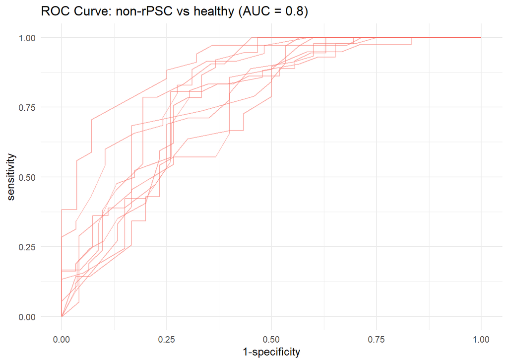

```r
roc_c
```

**rPSC effect**

```r
model_name <- paste("rPSC effect",level,segment)

# prepare the data
filt_ileum_uni_data <- binomial_prep_psc_effect(ileum_asv_tab,
                                                ileum_taxa_tab,
                                                ileum_metadata,
                                                rpsc_effect[[paste(segment,level)]],
                                                usage="ml_ra")
```

```
## Removing 1127 ASV(s)
```

```
## Removing 27 ASV(s)
```

```r
# fit the model
knn_model <- knn_binomial(filt_ileum_uni_data,
                              sample_method = "atypboot",
                              outcome="Group",
                              N=10,
                              reuse=TRUE,
                              file=model_name,
                              Q="Q2")

# ROC curve
roc_c <- roc_curve(knn_model, group)

# save the results
supplements_models[["models_summ"]][["knn_model_ra"]][[model_name]] <- knn_model$model_summary

supplements_models[["roc_cs"]][["knn_model_ra"]][[model_name]] <- knn_model$kfold_rocobjs

# see the results
knn_model$model_summary %>% t()
```

```
##                                       [,1]
## k                               30.0000000
## auc                              0.7507937
## auc_optimism_corrected           0.6012685
## auc_optimism_corrected_CIL       0.4582148
## auc_optimism_corrected_CIU       0.7079090
## accuracy                         0.7608696
## accuracy_optimism_corrected      0.7445805
## accuracy_optimism_corrected_CIL  0.6713542
## accuracy_optimism_corrected_CIU  0.8070913
```

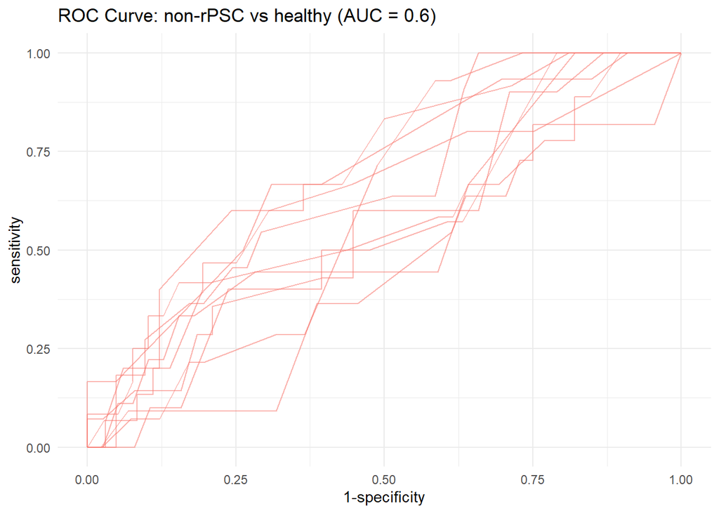

```r
roc_c
```

###### Genus level

```r
level="genus"
```

Aggregate taxa

```r
genus_data <- aggregate_taxa(ileum_asv_tab,
                             ileum_taxa_tab,
                             taxonomic_level = level)

ileum_genus_tab <- genus_data[[1]]
ileum_genus_taxa_tab <- genus_data[[2]]
```

**rPSC vs non-rPSC**

```r
group <- c("rPSC","non-rPSC")
comparison_name <- paste0(group[1], " vs ",group[2])
```

```r
model_name <- paste(comparison_name,level,segment)

# prepare the data
filt_ileum_uni_data <- binomial_prep(ileum_genus_tab,
                                     ileum_genus_taxa_tab,
                                     ileum_metadata,
                                     group,
                                     usage="ml_ra")
```

```
## Removing 55 ASV(s)
```

```
## Removing 2 ASV(s)
```

```r
# fit the model
knn_model <- knn_binomial(filt_ileum_uni_data,
                              sample_method = "atypboot",
                              outcome="Group",
                              N=10,
                              reuse=TRUE,
                              file=model_name,
                              Q="Q2")

# ROC curve
roc_c <- roc_curve(knn_model, group)

# save the results
supplements_models[["models_summ"]][["knn_model_ra"]][[model_name]] <- knn_model$model_summary

supplements_models[["roc_cs"]][["knn_model_ra"]][[model_name]] <- knn_model$kfold_rocobjs

# see the results
knn_model$model_summary %>% t()
```

```
##                                       [,1]
## k                               12.0000000
## auc                              0.7204906
## auc_optimism_corrected           0.5247021
## auc_optimism_corrected_CIL       0.4504327
## auc_optimism_corrected_CIU       0.6254728
## accuracy                         0.7681159
## accuracy_optimism_corrected      0.7526688
## accuracy_optimism_corrected_CIL  0.6754902
## accuracy_optimism_corrected_CIU  0.7916667
```

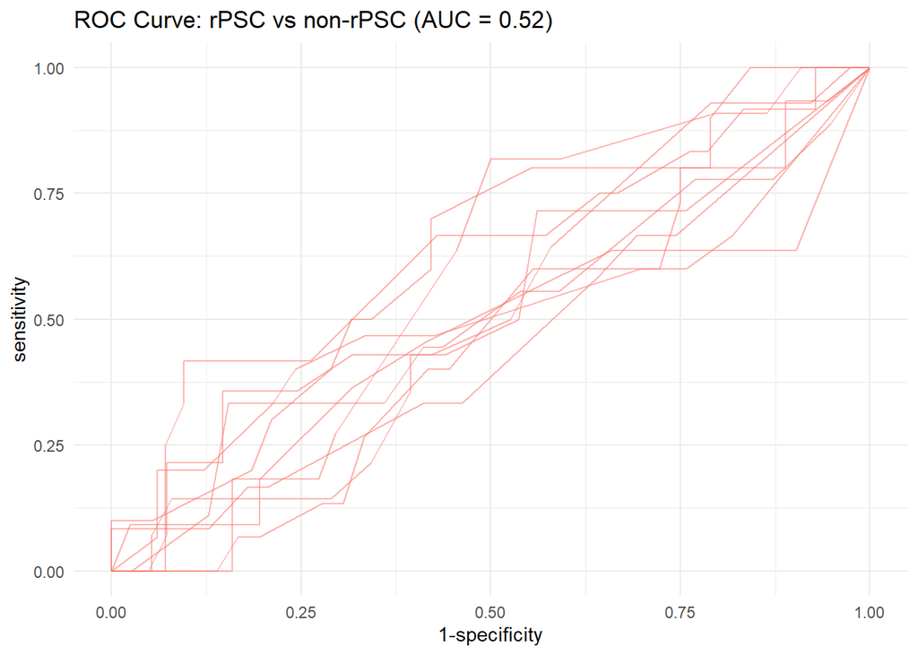

```r
roc_c
```

**rPSC vs healthy**

```r
group <- c("rPSC","healthy")
comparison_name <- paste0(group[1], " vs ",group[2])
```

```r
model_name <- paste(comparison_name,level,segment)

# prepare the data
filt_ileum_uni_data <- binomial_prep(ileum_genus_tab,
                                     ileum_genus_taxa_tab,
                                     ileum_metadata,
                                     group,
                                     usage="ml_ra")
```

```
## Removing 67 ASV(s)
```

```
## Removing 4 ASV(s)
```

```r
# fit the model
knn_model <- knn_binomial(filt_ileum_uni_data,
                              sample_method = "atypboot",
                              outcome="Group",
                              N=10,
                              reuse=TRUE,
                              file=model_name,
                              Q="Q2")

# ROC curve
roc_c <- roc_curve(knn_model, group)

# save the results
supplements_models[["models_summ"]][["knn_model_ra"]][[model_name]] <- knn_model$model_summary

supplements_models[["roc_cs"]][["knn_model_ra"]][[model_name]] <- knn_model$kfold_rocobjs

# see the results
knn_model$model_summary %>% t()
```

```
##                                       [,1]
## k                               11.0000000
## auc                              0.8897883
## auc_optimism_corrected           0.7275478
## auc_optimism_corrected_CIL       0.5635054
## auc_optimism_corrected_CIU       0.8718839
## accuracy                         0.7641509
## accuracy_optimism_corrected      0.7317397
## accuracy_optimism_corrected_CIL  0.6065789
## accuracy_optimism_corrected_CIU  0.8249554
```

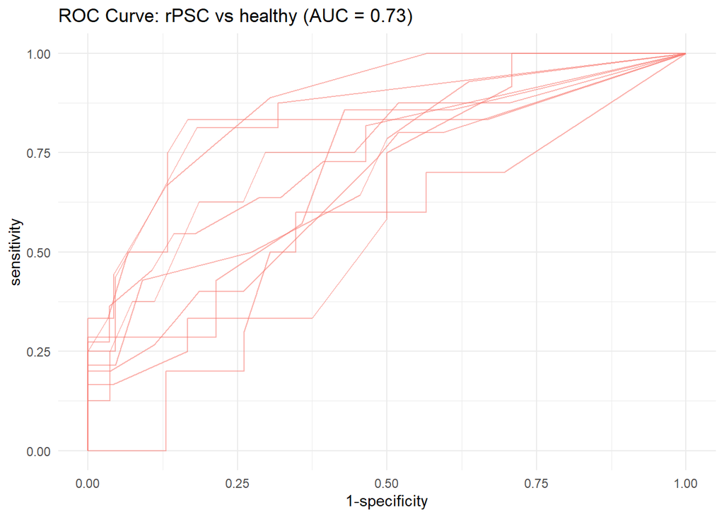

```r
roc_c
```

**non-rPSC vs healthy**

```r
group <- c("non-rPSC","healthy")
comparison_name <- paste0(group[1], " vs ",group[2])
```

```r
model_name <- paste(comparison_name,level,segment)

# prepare the data
filt_ileum_uni_data <- binomial_prep(ileum_genus_tab,
                                     ileum_genus_taxa_tab,
                                     ileum_metadata,
                                     group,
                                     usage="ml_ra")
```

```
## Removing 24 ASV(s)
```

```
## Removing 2 ASV(s)
```

```r
# fit the model
knn_model <- knn_binomial(filt_ileum_uni_data,
                              sample_method = "atypboot",
                              outcome="Group",
                              N=10,
                              reuse=TRUE,
                              file=model_name,
                              Q="Q2")

# ROC curve
roc_c <- roc_curve(knn_model, group)

# save the results
supplements_models[["models_summ"]][["knn_model_ra"]][[model_name]] <- knn_model$model_summary

supplements_models[["roc_cs"]][["knn_model_ra"]][[model_name]] <- knn_model$kfold_rocobjs

# see the results
knn_model$model_summary %>% t()
```

```
##                                       [,1]
## k                               25.0000000
## auc                              0.8847358
## auc_optimism_corrected           0.8273708
## auc_optimism_corrected_CIL       0.7218575
## auc_optimism_corrected_CIU       0.8887756
## accuracy                         0.8202247
## accuracy_optimism_corrected      0.7458772
## accuracy_optimism_corrected_CIL  0.6807692
## accuracy_optimism_corrected_CIU  0.8203125
```

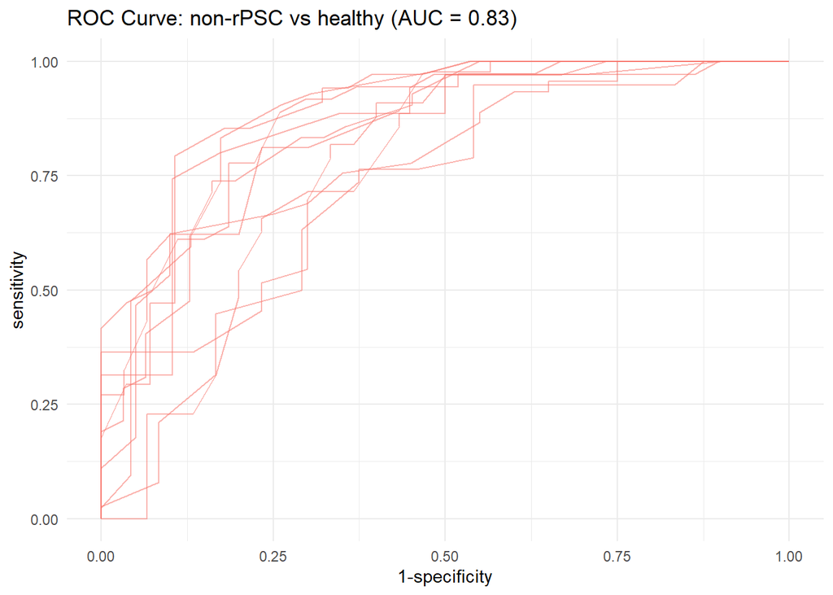

```r
roc_c
```

**rPSC effect**

```r
model_name <- paste("rPSC effect",level,segment)

# prepare the data
filt_ileum_uni_data <- binomial_prep_psc_effect(ileum_genus_tab,
                                                ileum_genus_taxa_tab,
                                                ileum_metadata,
                                                rpsc_effect[[paste(segment,level)]],
                                                usage="ml_ra")
```

```
## Removing 55 ASV(s)
```

```
## Removing 2 ASV(s)
```

```r
# fit the model
knn_model <- knn_binomial(filt_ileum_uni_data,
                              sample_method = "atypboot",
                              outcome="Group",
                              N=10,
                              reuse=TRUE,
                              file=model_name,
                              Q="Q2")

# ROC curve
roc_c <- roc_curve(knn_model, group)

# save the results
supplements_models[["models_summ"]][["knn_model_ra"]][[model_name]] <- knn_model$model_summary

supplements_models[["roc_cs"]][["knn_model_ra"]][[model_name]] <- knn_model$kfold_rocobjs

# see the results
knn_model$model_summary %>% t()
```

```
##                                       [,1]
## k                               13.0000000
## auc                              0.7734488
## auc_optimism_corrected           0.5463875
## auc_optimism_corrected_CIL       0.3858295
## auc_optimism_corrected_CIU       0.6525333
## accuracy                         0.7753623
## accuracy_optimism_corrected      0.7408946
## accuracy_optimism_corrected_CIL  0.6865502
## accuracy_optimism_corrected_CIU  0.7885417
```

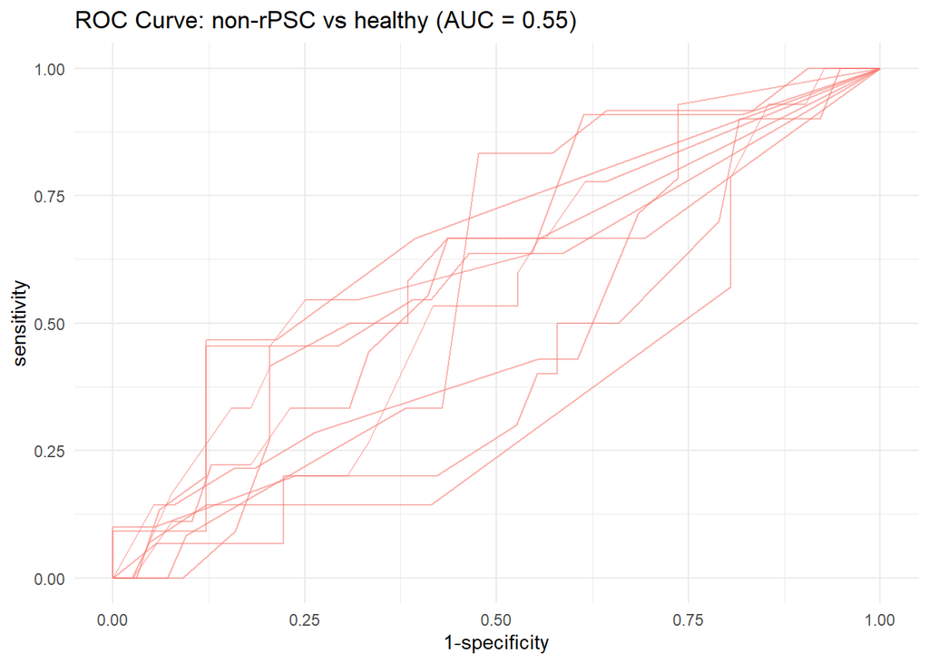

```r
roc_c
```

##### Random Forest

###### ASV level

```r
level="ASV"
```

*rPSC vs non-rPSC*

```r
group <- c("rPSC","non-rPSC")
comparison_name <- paste0(group[1], " vs ",group[2])
```

```r
model_name <- paste(comparison_name,level,segment)

# prepare the data
filt_ileum_uni_data <- binomial_prep(ileum_asv_tab,
                                     ileum_taxa_tab,
                                     ileum_metadata,
                                     group, usage="ml_ra")
```

```
## Removing 1127 ASV(s)
```

```
## Removing 27 ASV(s)
```

```r
# fit the model
rf_model <- rf_binomial(filt_ileum_uni_data,
                              sample_method = "atypboot",
                              outcome="Group",
                              N=10,
                              reuse=TRUE,
                              file=model_name,
                              Q="Q2")

# ROC curve
roc_c <- roc_curve(rf_model, group)

# save the results
supplements_models[["models_summ"]][["rf_model_ra"]][[model_name]] <- rf_model$model_summary

supplements_models[["roc_cs"]][["rf_model_ra"]][[model_name]] <- rf_model$kfold_rocobjs

# see the results
rf_model$model_summary %>% t()
```

```
##                                 [,1]
## mtry                            "45"
## splitrule                       "gini"
## min.node.size                   "5"
## auc                             "1"
## auc_optimism_corrected          "0.6294299"
## auc_optimism_corrected_CIL      "0.5442163"
## auc_optimism_corrected_CIU      "0.7521896"
## accuracy                        "1"
## accuracy_optimism_corrected     "0.7583885"
## accuracy_optimism_corrected_CIL "0.691636"
## accuracy_optimism_corrected_CIU "0.798125"
```

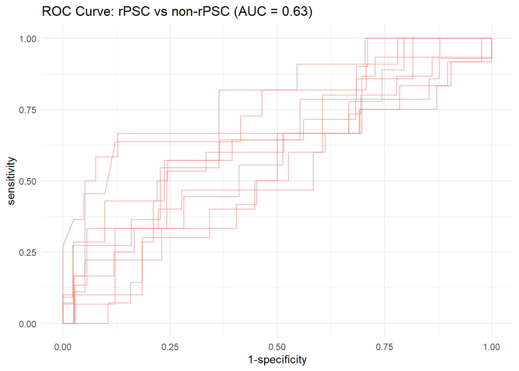

```r
roc_c
```

**rPSC vs healthy**

```r
group <- c("rPSC","healthy")
comparison_name <- paste0(group[1], " vs ",group[2])
```

```r
model_name <- paste(comparison_name,level,segment)

# prepare the data
filt_ileum_uni_data <- binomial_prep(ileum_asv_tab,
                                     ileum_taxa_tab,
                                     ileum_metadata,
                                     group, usage="ml_ra")
```

```
## Removing 1214 ASV(s)
```

```
## Removing 122 ASV(s)
```

```r
# fit the model
rf_model <- rf_binomial(filt_ileum_uni_data,
                              sample_method = "atypboot",
                              outcome="Group",
                              N=10,
                              reuse=TRUE,
                              file=model_name,
                              Q="Q2")

# ROC curve
roc_c <- roc_curve(rf_model, group)

# save the results
supplements_models[["models_summ"]][["rf_model_ra"]][[model_name]] <- rf_model$model_summary

supplements_models[["roc_cs"]][["rf_model_ra"]][[model_name]] <- rf_model$kfold_rocobjs


# see the results
rf_model$model_summary %>% t()
```

```
##                                 [,1]
## mtry                            "283"
## splitrule                       "gini"
## min.node.size                   "5"
## auc                             "1"
## auc_optimism_corrected          "0.9400127"
## auc_optimism_corrected_CIL      "0.8682876"
## auc_optimism_corrected_CIU      "0.9915483"
## accuracy                        "1"
## accuracy_optimism_corrected     "0.8348226"
## accuracy_optimism_corrected_CIL "0.7580357"
## accuracy_optimism_corrected_CIU "0.8881746"
```

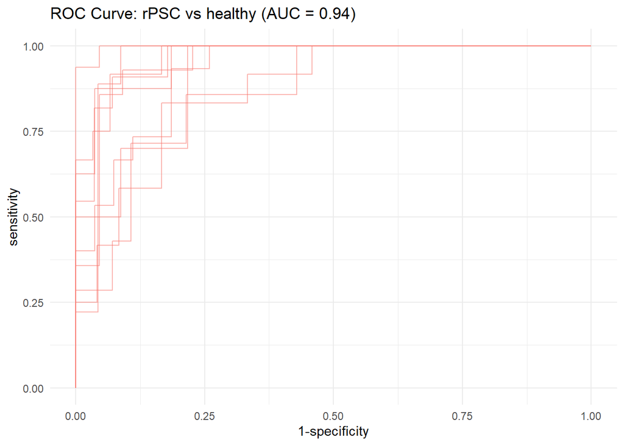

```r
roc_c
```

**non-rPSC vs healthy**

```r
group <- c("non-rPSC","healthy")
comparison_name <- paste0(group[1], " vs ",group[2])
```

```r
model_name <- paste(comparison_name,level,segment)

# prepare the data
filt_ileum_uni_data <- binomial_prep(ileum_asv_tab,
                                     ileum_taxa_tab,
                                     ileum_metadata,
                                     group, usage="ml_ra")
```

```
## Removing 392 ASV(s)
```

```
## Removing 91 ASV(s)
```

```r
# fit the model
rf_model <- rf_binomial(filt_ileum_uni_data,
                              sample_method = "atypboot",
                              outcome="Group",
                              N=10,
                              reuse=TRUE,
                              file=model_name,
                              Q="Q2")

# ROC curve
roc_c <- roc_curve(rf_model, group)

# save the results
supplements_models[["models_summ"]][["rf_model_ra"]][[model_name]] <- rf_model$model_summary

supplements_models[["roc_cs"]][["rf_model_ra"]][[model_name]] <- rf_model$kfold_rocobjs


# see the results
rf_model$model_summary %>% t()
```

```
##                                 [,1]
## mtry                            "65"
## splitrule                       "gini"
## min.node.size                   "2"
## auc                             "1"
## auc_optimism_corrected          "0.909026"
## auc_optimism_corrected_CIL      "0.8608662"
## auc_optimism_corrected_CIU      "0.9626096"
## accuracy                        "1"
## accuracy_optimism_corrected     "0.8424148"
## accuracy_optimism_corrected_CIL "0.7595179"
## accuracy_optimism_corrected_CIU "0.9007692"
```

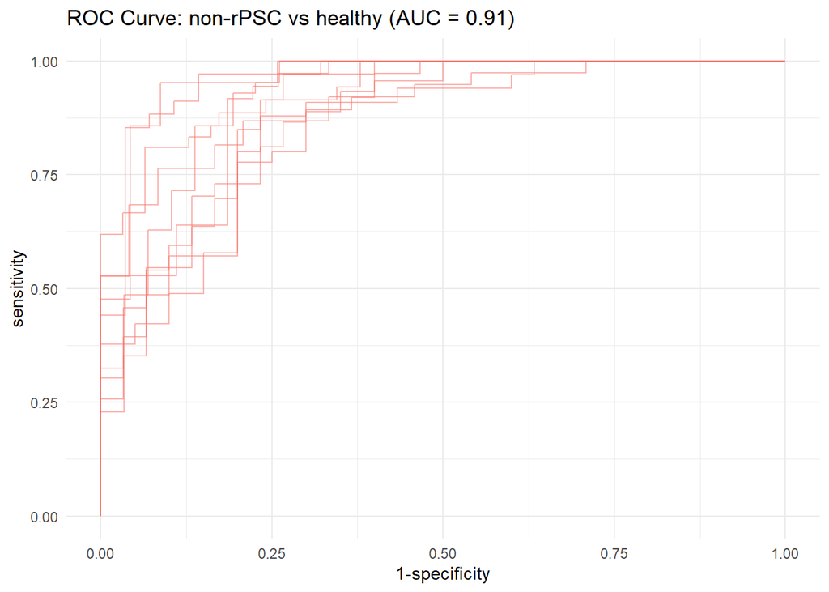

```r
roc_c
```

**rPSC effect**

```r
model_name <- paste("rPSC effect",level,segment)

# prepare the data
filt_ileum_uni_data <- binomial_prep_psc_effect(ileum_asv_tab,
                                                ileum_taxa_tab,
                                                ileum_metadata,
                                                rpsc_effect[[paste(segment,level)]],
                                                usage="ml_ra")
```

```
## Removing 1127 ASV(s)
```

```
## Removing 27 ASV(s)
```

```r
# fit the model
rf_model <- rf_binomial(filt_ileum_uni_data,
                              sample_method = "atypboot",
                              outcome="Group",
                              N=10,
                              reuse=TRUE,
                              file=model_name,
                              Q="Q2")

# ROC curve
roc_c <- roc_curve(rf_model, group)

# save the results
supplements_models[["models_summ"]][["rf_model_ra"]][[model_name]] <- rf_model$model_summary

supplements_models[["roc_cs"]][["rf_model_ra"]][[model_name]] <- rf_model$kfold_rocobjs


# see the results
rf_model$model_summary %>% t()
```

```
##                                 [,1]
## mtry                            "1"
## splitrule                       "gini"
## min.node.size                   "2"
## auc                             "0.9943723"
## auc_optimism_corrected          "0.63524"
## auc_optimism_corrected_CIL      "0.5536503"
## auc_optimism_corrected_CIU      "0.7122773"
## accuracy                        "0.8623188"
## accuracy_optimism_corrected     "0.7325812"
## accuracy_optimism_corrected_CIL "0.6865502"
## accuracy_optimism_corrected_CIU "0.7682127"
```

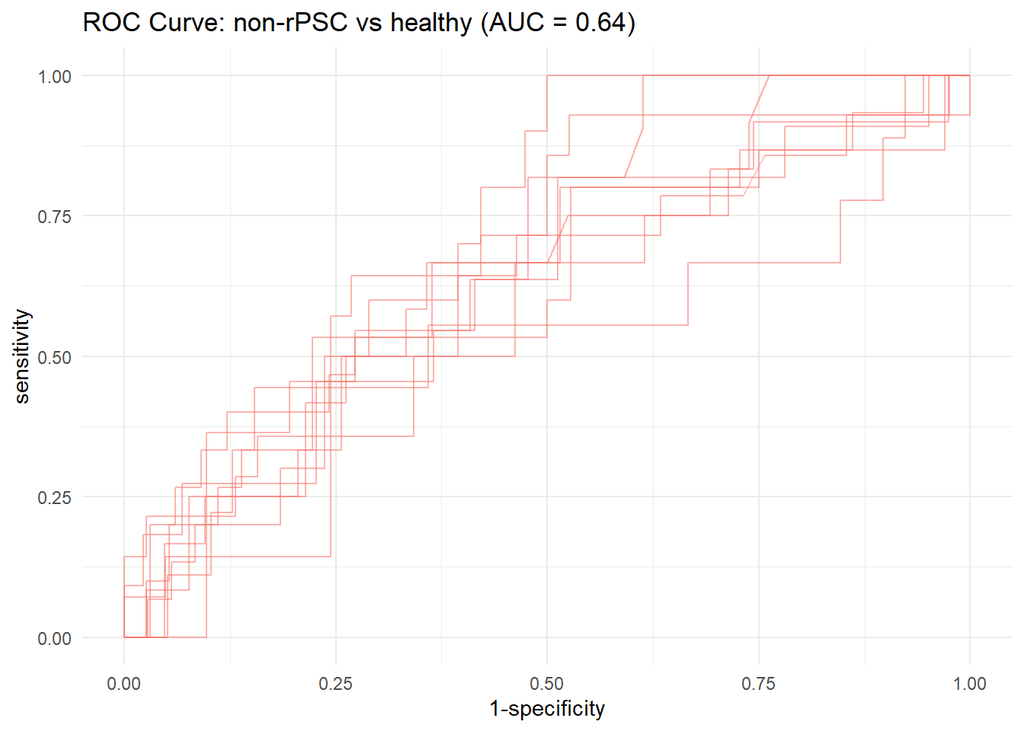

```r
roc_c
```

###### Genus level

```r
level="genus"
```

Aggregate taxa

```r
genus_data <- aggregate_taxa(ileum_asv_tab,
                             ileum_taxa_tab,
                             taxonomic_level = level)

ileum_genus_tab <- genus_data[[1]]
ileum_genus_taxa_tab <- genus_data[[2]]
```

**rPSC vs non-rPSC**

```r
group <- c("rPSC","non-rPSC")
comparison_name <- paste0(group[1], " vs ",group[2])
```

```r
model_name <- paste(comparison_name,level,segment)

# prepare the data
filt_ileum_uni_data <- binomial_prep(ileum_genus_tab,
                                     ileum_genus_taxa_tab,
                                     ileum_metadata,
                                     group,
                                     usage="ml_ra")
```

```
## Removing 55 ASV(s)
```

```
## Removing 2 ASV(s)
```

```r
# fit the model
rf_model <- rf_binomial(filt_ileum_uni_data,
                              sample_method = "atypboot",
                              outcome="Group",
                              N=10,
                              reuse=TRUE,
                              file=model_name,
                              Q="Q2")

# ROC curve
roc_c <- roc_curve(rf_model, group)

# save the results
supplements_models[["models_summ"]][["rf_model_ra"]][[model_name]] <- rf_model$model_summary

supplements_models[["roc_cs"]][["rf_model_ra"]][[model_name]] <- rf_model$kfold_rocobjs


# see the results
rf_model$model_summary %>% t()
```

```
##                                 [,1]
## mtry                            "1"
## splitrule                       "gini"
## min.node.size                   "2"
## auc                             "1"
## auc_optimism_corrected          "0.6340995"
## auc_optimism_corrected_CIL      "0.560939"
## auc_optimism_corrected_CIU      "0.7418293"
## accuracy                        "0.9057971"
## accuracy_optimism_corrected     "0.7350835"
## accuracy_optimism_corrected_CIL "0.6862745"
## accuracy_optimism_corrected_CIU "0.7708333"
```

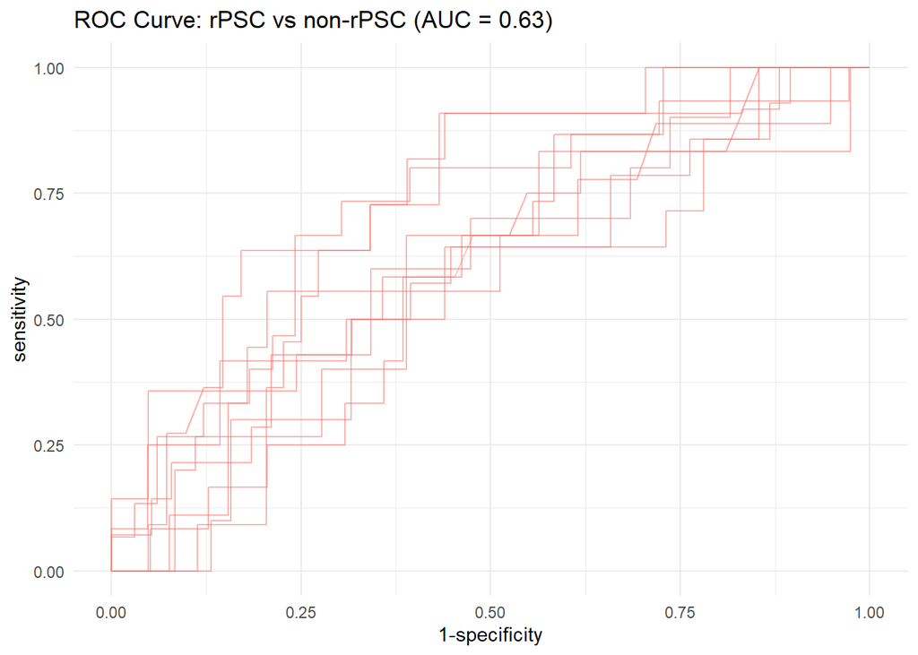

```r
roc_c
```

**rPSC vs healthy**

```r
group <- c("rPSC","healthy")
comparison_name <- paste0(group[1], " vs ",group[2])
```

```r
model_name <- paste(comparison_name,level,segment)

# prepare the data
filt_ileum_uni_data <- binomial_prep(ileum_genus_tab,
                                     ileum_genus_taxa_tab,
                                     ileum_metadata,
                                     group,
                                     usage="ml_ra")
```

```
## Removing 67 ASV(s)
```

```
## Removing 4 ASV(s)
```

```r
# fit the model
rf_model <- rf_binomial(filt_ileum_uni_data,
                              sample_method = "atypboot",
                              outcome="Group",
                              N=10,
                              reuse=TRUE,
                              file=model_name,
                              Q="Q2")

# ROC curve
roc_c <- roc_curve(rf_model, group)

# save the results
supplements_models[["models_summ"]][["rf_model_ra"]][[model_name]] <- rf_model$model_summary

supplements_models[["roc_cs"]][["rf_model_ra"]][[model_name]] <- rf_model$kfold_rocobjs


# see the results
rf_model$model_summary %>% t()
```

```
##                                 [,1]
## mtry                            "203"
## splitrule                       "gini"
## min.node.size                   "2"
## auc                             "1"
## auc_optimism_corrected          "0.9497313"
## auc_optimism_corrected_CIL      "0.8715106"
## auc_optimism_corrected_CIU      "0.9941356"
## accuracy                        "1"
## accuracy_optimism_corrected     "0.8596052"
## accuracy_optimism_corrected_CIL "0.7941587"
## accuracy_optimism_corrected_CIU "0.9322768"
```

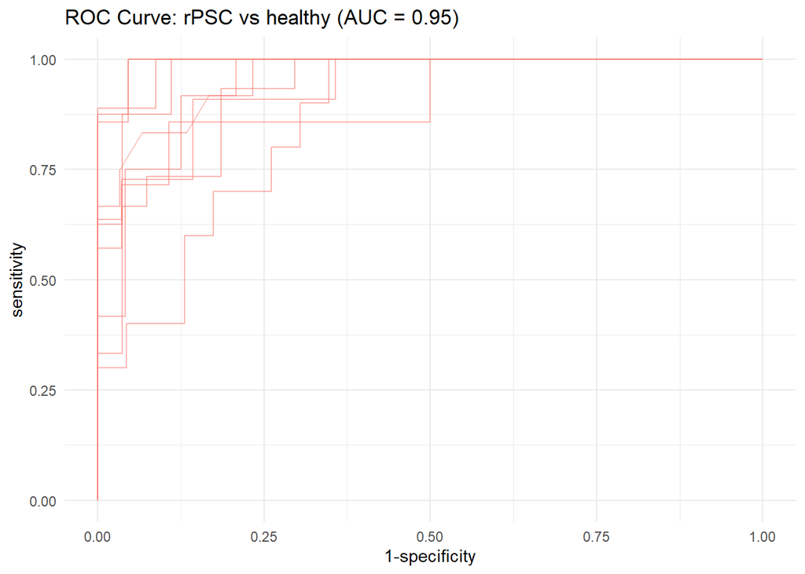

```r
roc_c
```

**non-rPSC vs healthy**

```r
group <- c("non-rPSC","healthy")
comparison_name <- paste0(group[1], " vs ",group[2])
```

```r
model_name <- paste(comparison_name,level,segment)

# prepare the data
filt_ileum_uni_data <- binomial_prep(ileum_genus_tab,
                                     ileum_genus_taxa_tab,
                                     ileum_metadata,
                                     group,
                                     usage="ml_ra")
```

```
## Removing 24 ASV(s)
```

```
## Removing 2 ASV(s)
```

```r
# fit the model
rf_model <- rf_binomial(filt_ileum_uni_data,
                              sample_method = "atypboot",
                              outcome="Group",
                              N=10,
                              reuse=TRUE,
                              file=model_name,
                              Q="Q2")

# ROC curve
roc_c <- roc_curve(rf_model, group)

# save the results
supplements_models[["models_summ"]][["rf_model_ra"]][[model_name]] <- rf_model$model_summary

supplements_models[["roc_cs"]][["rf_model_ra"]][[model_name]] <- rf_model$kfold_rocobjs


# see the results
rf_model$model_summary %>% t()
```

```
##                                 [,1]
## mtry                            "7"
## splitrule                       "gini"
## min.node.size                   "2"
## auc                             "1"
## auc_optimism_corrected          "0.9295135"
## auc_optimism_corrected_CIL      "0.8657029"
## auc_optimism_corrected_CIU      "0.9839446"
## accuracy                        "1"
## accuracy_optimism_corrected     "0.8739723"
## accuracy_optimism_corrected_CIL "0.8014516"
## accuracy_optimism_corrected_CIU "0.9344505"
```

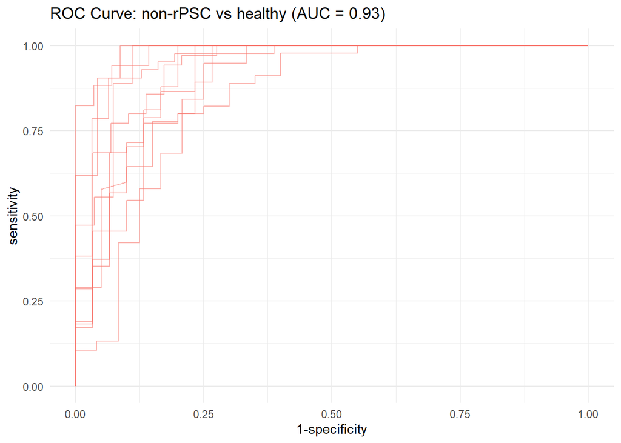

```r
roc_c
```

**rPSC effect**

```r
model_name <- paste("rPSC effect",level,segment)

# prepare the data
filt_ileum_uni_data <- binomial_prep_psc_effect(ileum_genus_tab,
                                                ileum_genus_taxa_tab,
                                                ileum_metadata,
                                                rpsc_effect[[paste(segment,level)]],
                                                usage="ml_ra")
```

```
## Removing 55 ASV(s)
```

```
## Removing 2 ASV(s)
```

```r
# fit the model
rf_model <- rf_binomial(filt_ileum_uni_data,
                              sample_method = "atypboot",
                              outcome="Group",
                              N=10,
                              reuse=TRUE,
                              file=model_name,
                              Q="Q2")

# ROC curve
roc_c <- roc_curve(rf_model, group)

# save the results
supplements_models[["models_summ"]][["rf_model_ra"]][[model_name]] <- rf_model$model_summary

supplements_models[["roc_cs"]][["rf_model_ra"]][[model_name]] <- rf_model$kfold_rocobjs


# see the results
rf_model$model_summary %>% t()
```

```
##                                 [,1]
## mtry                            "1"
## splitrule                       "gini"
## min.node.size                   "5"
## auc                             "1"
## auc_optimism_corrected          "0.6155945"
## auc_optimism_corrected_CIL      "0.5505441"
## auc_optimism_corrected_CIU      "0.711145"
## accuracy                        "0.8985507"
## accuracy_optimism_corrected     "0.7484636"
## accuracy_optimism_corrected_CIL "0.6514706"
## accuracy_optimism_corrected_CIU "0.8309943"
```

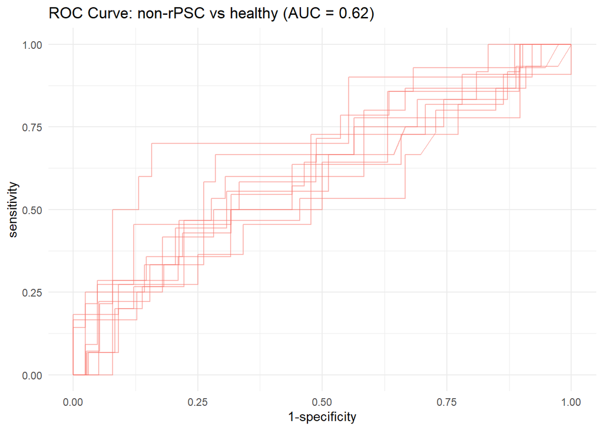

```r
roc_c
```

##### Gradient boosting

###### ASV level

```r
level="ASV"
```

*rPSC vs non-rPSC*

```r
group <- c("rPSC","non-rPSC")
comparison_name <- paste0(group[1], " vs ",group[2])
```

```r
model_name <- paste(comparison_name,level,segment)

# prepare the data
filt_ileum_uni_data <- binomial_prep(ileum_asv_tab,
                                     ileum_taxa_tab,
                                     ileum_metadata,
                                     group, usage="ml_ra")
```

```
## Removing 1127 ASV(s)
```

```
## Removing 27 ASV(s)
```

```r
# fit the model
gbm_model <- gbm_binomial(filt_ileum_uni_data,
                              sample_method = "atypboot",
                              outcome="Group",
                              N=10,
                              reuse=TRUE,
                              file=model_name,
                              Q="Q2")

# ROC curve
roc_c <- roc_curve(gbm_model, group)

# save the results
supplements_models[["models_summ"]][["gbm_model_ra"]][[model_name]] <- gbm_model$model_summary

supplements_models[["roc_cs"]][["gbm_model_ra"]][[model_name]] <- gbm_model$kfold_rocobjs

# see the results
gbm_model$model_summary %>% t()
```

```
##                                        [,1]
## n.trees                         100.0000000
## interaction.depth                 1.0000000
## shrinkage                         0.1000000
## n.minobsinnode                   10.0000000
## auc                               0.9927850
## auc_optimism_corrected            0.5068135
## auc_optimism_corrected_CIL        0.4057158
## auc_optimism_corrected_CIU        0.5988107
## accuracy                          0.9275362
## accuracy_optimism_corrected       0.7426751
## accuracy_optimism_corrected_CIL   0.6710784
## accuracy_optimism_corrected_CIU   0.8096875
```

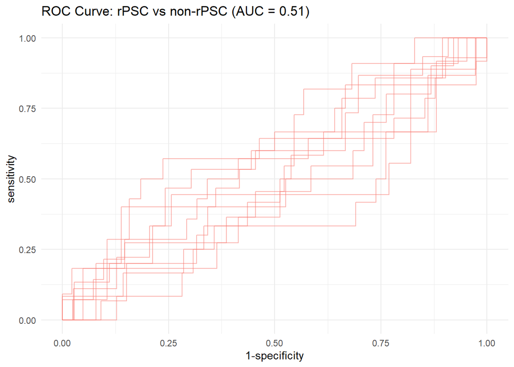

```r
roc_c
```

**rPSC vs healthy**

```r
group <- c("rPSC","healthy")
comparison_name <- paste0(group[1], " vs ",group[2])
```

```r
model_name <- paste(comparison_name,level,segment)

# prepare the data
filt_ileum_uni_data <- binomial_prep(ileum_asv_tab,
                                     ileum_taxa_tab,
                                     ileum_metadata,
                                     group, usage="ml_ra")
```

```
## Removing 1214 ASV(s)
```

```
## Removing 122 ASV(s)
```

```r
# fit the model
gbm_model <- gbm_binomial(filt_ileum_uni_data,
                              sample_method = "atypboot",
                              outcome="Group",
                              N=10,
                              reuse=TRUE,
                              file=model_name,
                              Q="Q2")

# ROC curve
roc_c <- roc_curve(gbm_model, group)

# save the results
supplements_models[["models_summ"]][["gbm_model_ra"]][[model_name]] <- gbm_model$model_summary

supplements_models[["roc_cs"]][["gbm_model_ra"]][[model_name]] <- gbm_model$kfold_rocobjs

# see the results
gbm_model$model_summary %>% t()
```

```
##                                        [,1]
## n.trees                         500.0000000
## interaction.depth                 3.0000000
## shrinkage                         0.1000000
## n.minobsinnode                   10.0000000
## auc                               1.0000000
## auc_optimism_corrected            0.9498809
## auc_optimism_corrected_CIL        0.9147640
## auc_optimism_corrected_CIU        0.9610390
## accuracy                          1.0000000
## accuracy_optimism_corrected       0.8697992
## accuracy_optimism_corrected_CIL   0.7827778
## accuracy_optimism_corrected_CIU   0.9342548
```

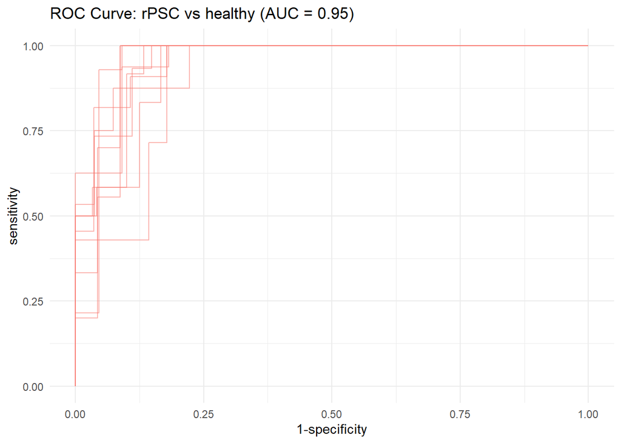

```r
roc_c
```

**non-rPSC vs healthy**

```r
group <- c("non-rPSC","healthy")
comparison_name <- paste0(group[1], " vs ",group[2])
```

```r
model_name <- paste(comparison_name,level,segment)

# prepare the data
filt_ileum_uni_data <- binomial_prep(ileum_asv_tab,
                                     ileum_taxa_tab,
                                     ileum_metadata,
                                     group, usage="ml_ra")
```

```
## Removing 392 ASV(s)
```

```
## Removing 91 ASV(s)
```

```r
# fit the model
gbm_model <- gbm_binomial(filt_ileum_uni_data,
                              sample_method = "atypboot",
                              outcome="Group",
                              N=10,
                              reuse=TRUE,
                              file=model_name,
                              Q="Q2")

# ROC curve
roc_c <- roc_curve(gbm_model, group)

# save the results
supplements_models[["models_summ"]][["gbm_model_ra"]][[model_name]] <- gbm_model$model_summary

supplements_models[["roc_cs"]][["gbm_model_ra"]][[model_name]] <- gbm_model$kfold_rocobjs

# see the results
gbm_model$model_summary %>% t()
```

```
##                                        [,1]
## n.trees                         200.0000000
## interaction.depth                 1.0000000
## shrinkage                         0.1000000
## n.minobsinnode                   10.0000000
## auc                               1.0000000
## auc_optimism_corrected            0.9222032
## auc_optimism_corrected_CIL        0.8621283
## auc_optimism_corrected_CIU        0.9842776
## accuracy                          1.0000000
## accuracy_optimism_corrected       0.8424909
## accuracy_optimism_corrected_CIL   0.7446429
## accuracy_optimism_corrected_CIU   0.9167308
```

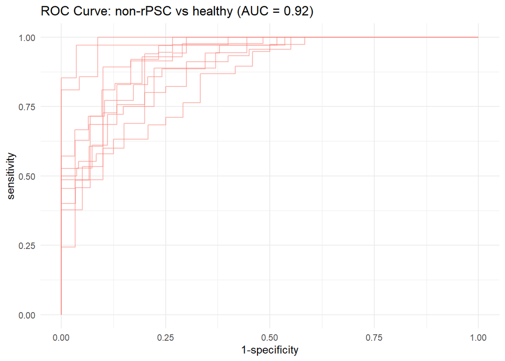

```r
roc_c
```

**rPSC effect**

```r
model_name <- paste("rPSC effect",level,segment)

# prepare the data
filt_ileum_uni_data <- binomial_prep_psc_effect(ileum_asv_tab,
                                                ileum_taxa_tab,
                                                ileum_metadata,
                                                rpsc_effect[[paste(segment,level)]],
                                                usage="ml_ra")
```

```
## Removing 1127 ASV(s)
```

```
## Removing 27 ASV(s)
```

```r
# fit the model
gbm_model <- gbm_binomial(filt_ileum_uni_data,
                              sample_method = "atypboot",
                              outcome="Group",
                              N=10,
                              reuse=TRUE,
                              file=model_name,
                              Q="Q2")

# ROC curve
roc_c <- roc_curve(gbm_model, group)

# save the results
supplements_models[["models_summ"]][["gbm_model_ra"]][[model_name]] <- gbm_model$model_summary

supplements_models[["roc_cs"]][["gbm_model_ra"]][[model_name]] <- gbm_model$kfold_rocobjs

# see the results
gbm_model$model_summary %>% t()
```

```
##                                        [,1]
## n.trees                         100.0000000
## interaction.depth                 1.0000000
## shrinkage                         0.1000000
## n.minobsinnode                   20.0000000
## auc                               0.8629149
## auc_optimism_corrected            0.6394533
## auc_optimism_corrected_CIL        0.5887956
## auc_optimism_corrected_CIU        0.7095918
## accuracy                          0.7971014
## accuracy_optimism_corrected       0.7336972
## accuracy_optimism_corrected_CIL   0.6912377
## accuracy_optimism_corrected_CIU   0.7694547
```

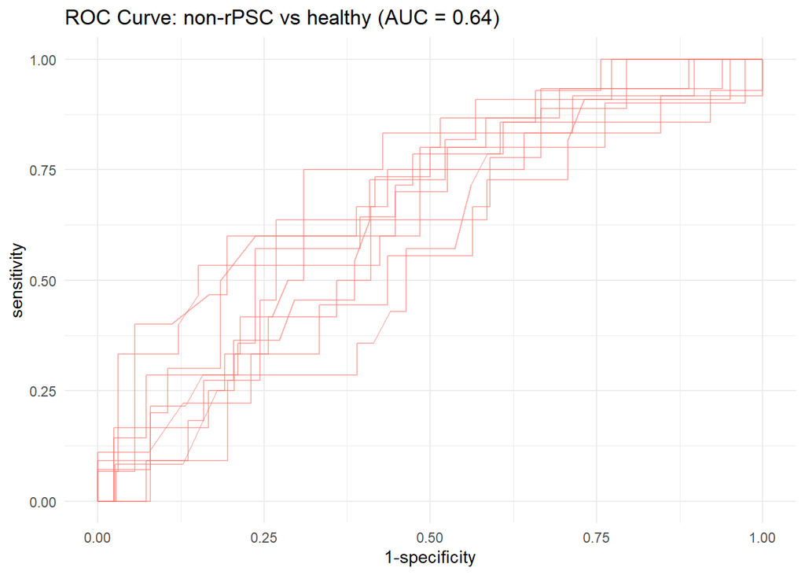

```r
roc_c
```

###### Genus level

```r
level="genus"
```

Aggregate taxa

```r
genus_data <- aggregate_taxa(ileum_asv_tab,
                             ileum_taxa_tab,
                             taxonomic_level = level)

ileum_genus_tab <- genus_data[[1]]
ileum_genus_taxa_tab <- genus_data[[2]]
```

**rPSC vs non-rPSC**

```r
group <- c("rPSC","non-rPSC")
comparison_name <- paste0(group[1], " vs ",group[2])
```

```r
model_name <- paste(comparison_name,level,segment)

# prepare the data
filt_ileum_uni_data <- binomial_prep(ileum_genus_tab,
                                     ileum_genus_taxa_tab,
                                     ileum_metadata,
                                     group,
                                     usage="ml_ra")
```

```
## Removing 55 ASV(s)
```

```
## Removing 2 ASV(s)
```

```r
# fit the model
gbm_model <- gbm_binomial(filt_ileum_uni_data,
                              sample_method = "atypboot",
                              outcome="Group",
                              N=10,
                              reuse=TRUE,
                              file=model_name,
                              Q="Q2")

# ROC curve
roc_c <- roc_curve(gbm_model, group)

# save the results
supplements_models[["models_summ"]][["gbm_model_ra"]][[model_name]] <- gbm_model$model_summary

supplements_models[["roc_cs"]][["gbm_model_ra"]][[model_name]] <- gbm_model$kfold_rocobjs

# see the results
gbm_model$model_summary %>% t()
```

```
##                                        [,1]
## n.trees                         200.0000000
## interaction.depth                 5.0000000
## shrinkage                         0.1000000
## n.minobsinnode                   20.0000000
## auc                               0.9985570
## auc_optimism_corrected            0.4493813
## auc_optimism_corrected_CIL        0.3608186
## auc_optimism_corrected_CIU        0.5408939
## accuracy                          0.9855072
## accuracy_optimism_corrected       0.6803940
## accuracy_optimism_corrected_CIL   0.6117034
## accuracy_optimism_corrected_CIU   0.7307692
```

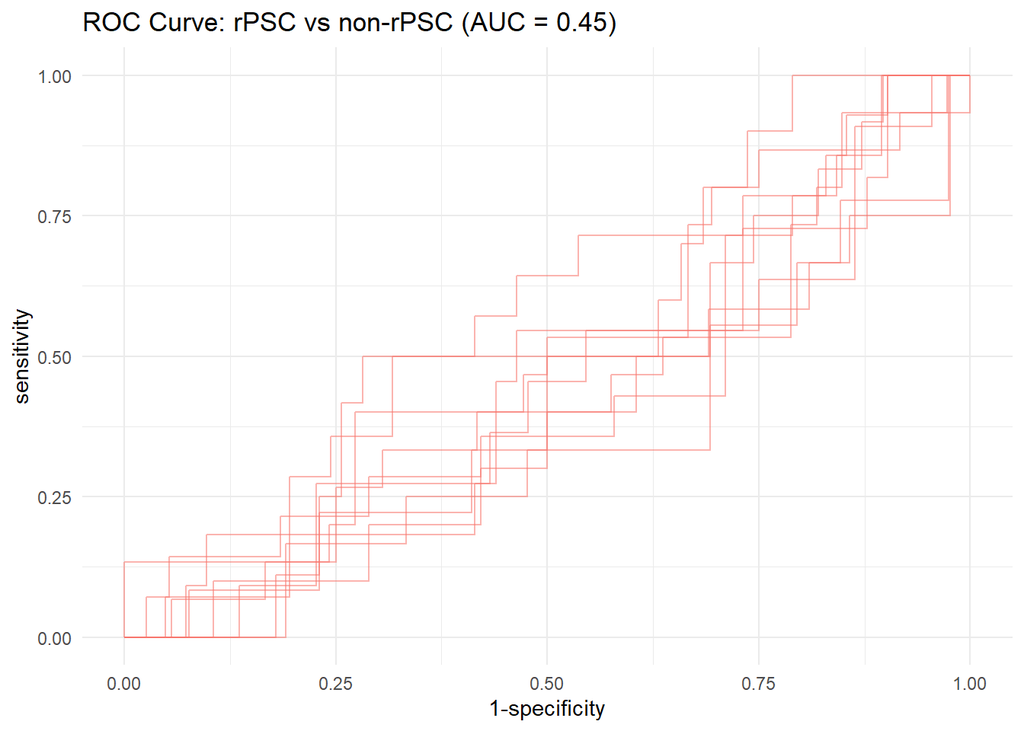

```r
roc_c
```

**rPSC vs healthy**

```r
group <- c("rPSC","healthy")
comparison_name <- paste0(group[1], " vs ",group[2])
```

```r
model_name <- paste(comparison_name,level,segment)

# prepare the data
filt_ileum_uni_data <- binomial_prep(ileum_genus_tab,
                                     ileum_genus_taxa_tab,
                                     ileum_metadata,
                                     group,
                                     usage="ml_ra")
```

```
## Removing 67 ASV(s)
```

```
## Removing 4 ASV(s)
```

```r
# fit the model
gbm_model <- gbm_binomial(filt_ileum_uni_data,
                              sample_method = "atypboot",
                              outcome="Group",
                              N=10,
                              reuse=TRUE,
                              file=model_name,
                              Q="Q2")

# ROC curve
roc_c <- roc_curve(gbm_model, group)

# save the results
supplements_models[["models_summ"]][["gbm_model_ra"]][[model_name]] <- gbm_model$model_summary

supplements_models[["roc_cs"]][["gbm_model_ra"]][[model_name]] <- gbm_model$kfold_rocobjs

# see the results
gbm_model$model_summary %>% t()
```

```
##                                        [,1]
## n.trees                         500.0000000
## interaction.depth                 5.0000000
## shrinkage                         0.1000000
## n.minobsinnode                   20.0000000
## auc                               1.0000000
## auc_optimism_corrected            0.9270279
## auc_optimism_corrected_CIL        0.8614764
## auc_optimism_corrected_CIU        0.9870724
## accuracy                          1.0000000
## accuracy_optimism_corrected       0.8379402
## accuracy_optimism_corrected_CIL   0.7424825
## accuracy_optimism_corrected_CIU   0.9322768
```

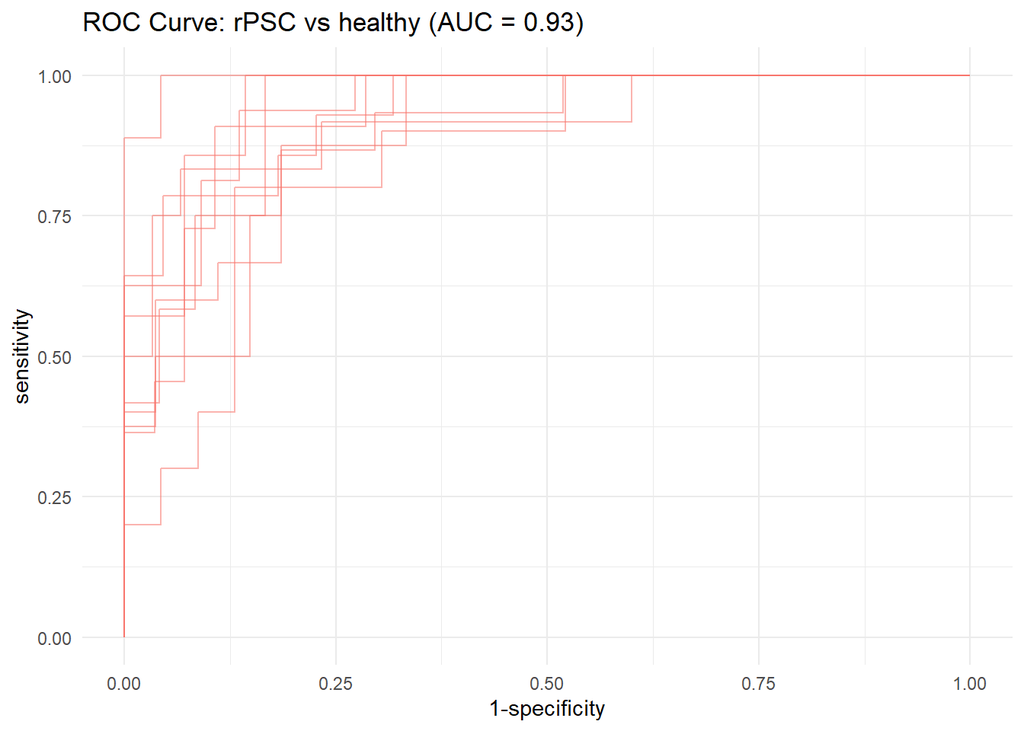

```r
roc_c
```

**non-rPSC vs healthy**

```r
group <- c("non-rPSC","healthy")
comparison_name <- paste0(group[1], " vs ",group[2])
```

```r
model_name <- paste(comparison_name,level,segment)

# prepare the data
filt_ileum_uni_data <- binomial_prep(ileum_genus_tab,
                                     ileum_genus_taxa_tab,
                                     ileum_metadata,
                                     group,
                                     usage="ml_ra")
```

```
## Removing 24 ASV(s)
```

```
## Removing 2 ASV(s)
```

```r
# fit the model
gbm_model <- gbm_binomial(filt_ileum_uni_data,
                              sample_method = "atypboot",
                              outcome="Group",
                              N=10,
                              reuse=TRUE,
                              file=model_name,
                              Q="Q2")

# ROC curve
roc_c <- roc_curve(gbm_model, group)

# save the results
supplements_models[["models_summ"]][["gbm_model_ra"]][[model_name]] <- gbm_model$model_summary

supplements_models[["roc_cs"]][["gbm_model_ra"]][[model_name]] <- gbm_model$kfold_rocobjs

# see the results
gbm_model$model_summary %>% t()
```

```
##                                        [,1]
## n.trees                         500.0000000
## interaction.depth                 1.0000000
## shrinkage                         0.1000000
## n.minobsinnode                   10.0000000
## auc                               1.0000000
## auc_optimism_corrected            0.9520042
## auc_optimism_corrected_CIL        0.8997708
## auc_optimism_corrected_CIU        0.9953416
## accuracy                          1.0000000
## accuracy_optimism_corrected       0.8951099
## accuracy_optimism_corrected_CIL   0.8153846
## accuracy_optimism_corrected_CIU   0.9646154
```

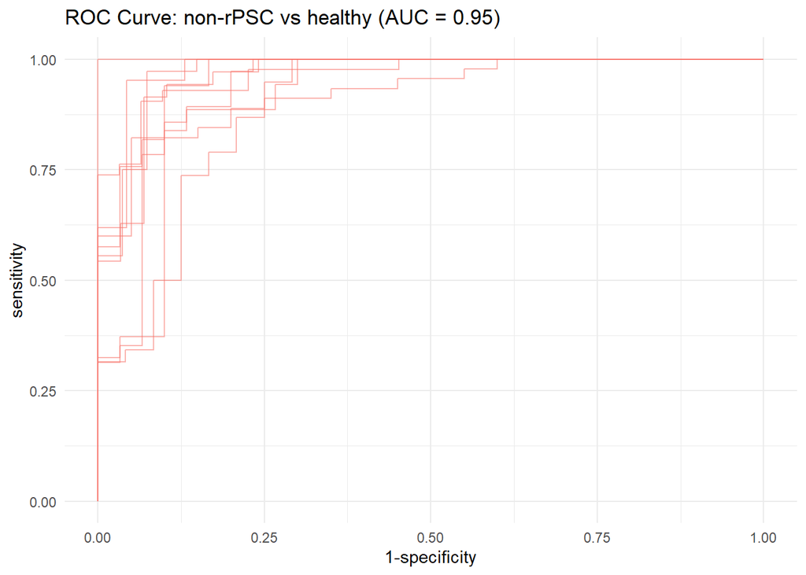

```r
roc_c
```

**rPSC effect**

```r
model_name <- paste("rPSC effect",level,segment)

# prepare the data
filt_ileum_uni_data <- binomial_prep_psc_effect(ileum_genus_tab,
                                                ileum_genus_taxa_tab,
                                                ileum_metadata,
                                                rpsc_effect[[paste(segment,level)]],
                                                usage="ml_ra")
```

```
## Removing 55 ASV(s)
```

```
## Removing 2 ASV(s)
```

```r
# fit the model
gbm_model <- gbm_binomial(filt_ileum_uni_data,
                              sample_method = "atypboot",
                              outcome="Group",
                              N=10,
                              reuse=TRUE,
                              file=model_name,
                              Q="Q2")

# ROC curve
roc_c <- roc_curve(gbm_model, group)

# save the results
supplements_models[["models_summ"]][["gbm_model_ra"]][[model_name]] <- gbm_model$model_summary

supplements_models[["roc_cs"]][["gbm_model_ra"]][[model_name]] <- gbm_model$kfold_rocobjs

# see the results
gbm_model$model_summary %>% t()
```

```
##                                        [,1]
## n.trees                         200.0000000
## interaction.depth                 5.0000000
## shrinkage                         0.1000000
## n.minobsinnode                   10.0000000
## auc                               1.0000000
## auc_optimism_corrected            0.6146849
## auc_optimism_corrected_CIL        0.5088894
## auc_optimism_corrected_CIU        0.7767575
## accuracy                          1.0000000
## accuracy_optimism_corrected       0.7447143
## accuracy_optimism_corrected_CIL   0.6514706
## accuracy_optimism_corrected_CIU   0.8088542
```

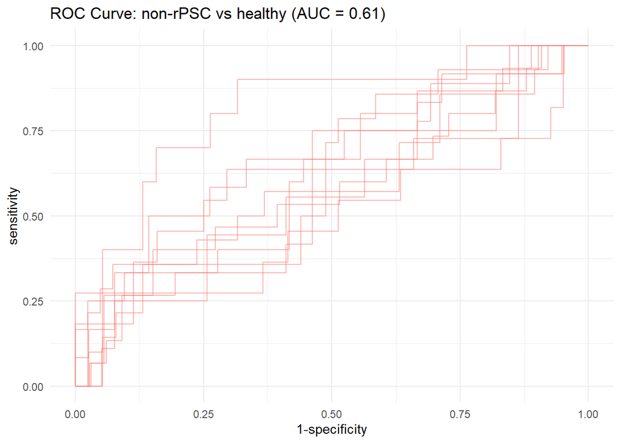

```r
roc_c
```

#### Saving results

```r
models_list <- list()

for (model_name in names(supplements_models$models_summ)){
  df <- do.call(rbind, supplements_models$models_summ[[model_name]])
  models_list[[model_name]] <- df
}

write.xlsx(models_list,
           file=file.path(path,paste0("supplements_models_",segment,".xlsx")),
           rowNames=TRUE)
```

## Results overview

#### Alpha diversity

**Models**

```r
pc_observed[[segment]]
```

|  | Estimate | Std..Error | t.value | Pr...t.. | p.adj | sig |
| --- | --- | --- | --- | --- | --- | --- |
| non-rPSC vs GrouprPSC | -12.198718 | 11.972362 | -1.0189065 | 0.310083441 | 0.34884387 |  |
| non-rPSC , rPSC - CZ vs NO | -21.485755 | 11.452444 | -1.8760848 | 0.062818941 | 0.14134262 |  |
| non-rPSC vs GrouprPSC:CountryNO | 9.346866 | 23.088211 | 0.4048329 | 0.686245897 | 0.68624590 |  |
| healthy vs GrouprPSC | -37.740991 | 12.284490 | -3.0722474 | 0.002724467 | 0.02452021 | * |
| healthy , rPSC - CZ vs NO | 11.203453 | 10.972561 | 1.0210427 | 0.309649819 | 0.34884387 |  |
| healthy vs GrouprPSC:CountryNO | -23.342342 | 21.354733 | -1.0930758 | 0.276935375 | 0.34884387 |  |
| healthy vs Groupnon-rPSC | -25.542273 | 9.322222 | -2.7399340 | 0.006785889 | 0.03053650 | * |
| healthy , non-rPSC - CZ vs NO | 11.203453 | 10.932714 | 1.0247641 | 0.306897047 | 0.34884387 |  |
| healthy vs Groupnon-rPSC:CountryNO | -32.689208 | 15.108242 | -2.1636673 | 0.031853578 | 0.09556073 |  |

```r
pc_shannon[[segment]]
```

|  | Estimate | Std..Error | t.value | Pr...t.. | p.adj | sig |
| --- | --- | --- | --- | --- | --- | --- |
| non-rPSC vs GrouprPSC | -0.101605556 | 0.1459293 | -0.69626539 | 0.48746859 | 0.7312029 |  |
| non-rPSC , rPSC - CZ vs NO | -0.349022228 | 0.1395921 | -2.50030009 | 0.01361502 | 0.1225352 |  |
| non-rPSC vs GrouprPSC:CountryNO | -0.006024121 | 0.2814188 | -0.02140625 | 0.98295343 | 0.9829534 |  |
| healthy vs GrouprPSC | -0.210477005 | 0.1402689 | -1.50052474 | 0.13656768 | 0.3206220 |  |
| healthy , rPSC - CZ vs NO | 0.005335114 | 0.1252888 | 0.04258252 | 0.96611758 | 0.9829534 |  |
| healthy vs GrouprPSC:CountryNO | -0.360381463 | 0.2438364 | -1.47796424 | 0.14249866 | 0.3206220 |  |
| healthy vs Groupnon-rPSC | -0.108871449 | 0.1148008 | -0.94835073 | 0.34426619 | 0.6196791 |  |
| healthy , non-rPSC - CZ vs NO | 0.005335114 | 0.1346336 | 0.03962690 | 0.96843601 | 0.9829534 |  |
| healthy vs Groupnon-rPSC:CountryNO | -0.354357342 | 0.1860542 | -1.90459184 | 0.05848297 | 0.2631733 |  |

```r
pc_simpson[[segment]]
```

|  | Estimate | Std..Error | t.value | Pr...t.. | p.adj | sig |
| --- | --- | --- | --- | --- | --- | --- |
| non-rPSC vs GrouprPSC | 0.0004324736 | 0.02252973 | 0.01919568 | 0.9847136 | 0.9847136 |  |
| non-rPSC , rPSC - CZ vs NO | -0.0339100953 | 0.02155134 | -1.57345644 | 0.1179713 | 0.5308709 |  |
| non-rPSC vs GrouprPSC:CountryNO | -0.0287135025 | 0.04344766 | -0.66087568 | 0.5098267 | 0.7674139 |  |
| healthy vs GrouprPSC | -0.0088419517 | 0.01769236 | -0.49976112 | 0.6183197 | 0.7674139 |  |
| healthy , rPSC - CZ vs NO | -0.0079174567 | 0.01580289 | -0.50101317 | 0.6174413 | 0.7674139 |  |
| healthy vs GrouprPSC:CountryNO | -0.0547061411 | 0.03075549 | -1.77874375 | 0.0782609 | 0.5308709 |  |
| healthy vs Groupnon-rPSC | -0.0092744253 | 0.01645717 | -0.56354910 | 0.5737866 | 0.7674139 |  |
| healthy , non-rPSC - CZ vs NO | -0.0079174567 | 0.01930029 | -0.41022478 | 0.6821457 | 0.7674139 |  |
| healthy vs Groupnon-rPSC:CountryNO | -0.0259926386 | 0.02667164 | -0.97454214 | 0.3311403 | 0.7674139 |  |

```r
pc_pielou[[segment]]
```

|  | Estimate | Std..Error | t.value | Pr...t.. | p.adj | sig |
| --- | --- | --- | --- | --- | --- | --- |
| non-rPSC vs GrouprPSC | -0.003990815 | 0.02165779 | -0.18426694 | 0.85408262 | 0.9464376 |  |
| non-rPSC , rPSC - CZ vs NO | -0.046827608 | 0.02071727 | -2.26031765 | 0.02541433 | 0.2287290 |  |
| non-rPSC vs GrouprPSC:CountryNO | -0.004526631 | 0.04176617 | -0.10838034 | 0.91385612 | 0.9464376 |  |
| healthy vs GrouprPSC | -0.001388751 | 0.02062095 | -0.06734662 | 0.94643760 | 0.9464376 |  |
| healthy , rPSC - CZ vs NO | -0.008520971 | 0.01841872 | -0.46262549 | 0.64461825 | 0.9464376 |  |
| healthy vs GrouprPSC:CountryNO | -0.042833267 | 0.03584641 | -1.19491089 | 0.23489285 | 0.7046786 |  |
| healthy vs Groupnon-rPSC | 0.002602064 | 0.01777940 | 0.14635270 | 0.88381239 | 0.9464376 |  |
| healthy , non-rPSC - CZ vs NO | -0.008520971 | 0.02085095 | -0.40866115 | 0.68329085 | 0.9464376 |  |
| healthy vs Groupnon-rPSC:CountryNO | -0.038306636 | 0.02881454 | -1.32942039 | 0.18544966 | 0.7046786 |  |

**Plots**

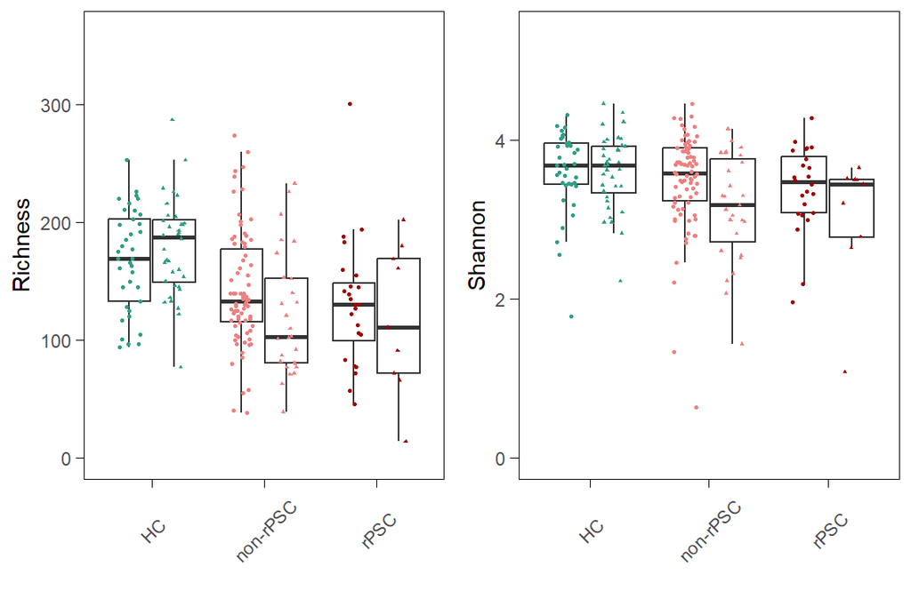

```r
alpha_div_plots[[paste(segment,"Country")]]
```

#### Beta diversity

**Main results**

```r
pairwise_aitchison_raw[[paste("genus", segment)]]
```

| pairs | Df | SumsOfSqs | F.Model | R2 | p.value | p.adjusted | sig |
| --- | --- | --- | --- | --- | --- | --- | --- |
| rPSC vs non-rPSC | 1 | 215.5793 | 1.2076295 | 0.008652444 | 0.107 | 0.1070 |  |
| rPSC vs healthy | 1 | 561.6965 | 3.3452390 | 0.030492804 | 0.001 | 0.0015 | ** |
| non-rPSC vs healthy | 1 | 760.2415 | 4.4312584 | 0.024156621 | 0.001 | 0.0015 | ** |
| rPSC vs non-rPSC , Country | 1 | 601.9289 | 3.3718784 | 0.024158890 | 0.001 | 0.0010 | *** |
| rPSC vs healthy , Country | 1 | 496.8405 | 2.9589830 | 0.026971970 | 0.001 | 0.0010 | *** |
| non-rPSC vs healthy , Country | 1 | 624.4738 | 3.6399025 | 0.019842613 | 0.001 | 0.0010 | *** |
| rPSC vs non-rPSC : Country | 1 | 156.1759 | 0.8740483 | 0.006268244 | 0.788 | 0.7880 |  |
| rPSC vs healthy : Country | 1 | 164.7427 | 0.9809604 | 0.008943386 | 0.464 | 0.6960 |  |
| non-rPSC vs healthy : Country | 1 | 209.9542 | 1.2253464 | 0.006671279 | 0.089 | 0.2670 |  |

**PCA**

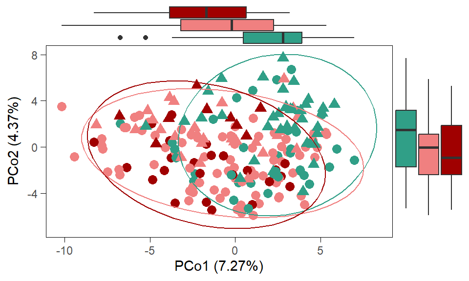

```r
pca_plots_list[[paste(segment,"genus custom")]]
```

**Supplements**

```r
knitr::kable(supplements_beta[!grepl("PCoA",names(supplements_beta)) & (grepl("genus",names(supplements_beta)))],
             digits = 3,
             caption = "Supplementary PERMANOVA results: Bray-curtis, Jaccard distances")
```

Supplementary PERMANOVA results: Bray-curtis, Jaccard distances

| pairs | Df | SumsOfSqs | F.Model | R2 | p.value | p.adjusted | sig |
| --- | --- | --- | --- | --- | --- | --- | --- |
| rPSC vs non-rPSC | 1 | 0.251 | 1.208 | 0.008 | 0.241 | 0.241 |  |
| rPSC vs healthy | 1 | 0.813 | 4.432 | 0.039 | 0.001 | 0.002 | ** |
| non-rPSC vs healthy | 1 | 1.241 | 6.538 | 0.034 | 0.001 | 0.002 | ** |
| rPSC vs non-rPSC , Country | 1 | 1.449 | 6.976 | 0.049 | 0.001 | 0.001 | *** |
| rPSC vs healthy , Country | 1 | 0.972 | 5.300 | 0.047 | 0.001 | 0.001 | *** |
| non-rPSC vs healthy , Country | 1 | 1.336 | 7.038 | 0.037 | 0.001 | 0.001 | *** |
| rPSC vs non-rPSC : Country | 1 | 0.151 | 0.724 | 0.005 | 0.803 | 0.803 |  |
| rPSC vs healthy : Country | 1 | 0.287 | 1.572 | 0.014 | 0.067 | 0.100 |  |
| non-rPSC vs healthy : Country | 1 | 0.354 | 1.873 | 0.010 | 0.011 | 0.033 | * |

| pairs | Df | SumsOfSqs | F.Model | R2 | p.value | p.adjusted | sig |
| --- | --- | --- | --- | --- | --- | --- | --- |
| rPSC vs non-rPSC | 1 | 0.337 | 1.138 | 0.008 | 0.241 | 0.241 |  |
| rPSC vs healthy | 1 | 0.887 | 3.269 | 0.030 | 0.001 | 0.002 | ** |
| non-rPSC vs healthy | 1 | 1.349 | 4.846 | 0.026 | 0.001 | 0.002 | ** |
| rPSC vs non-rPSC , Country | 1 | 1.460 | 4.927 | 0.035 | 0.001 | 0.001 | *** |
| rPSC vs healthy , Country | 1 | 1.092 | 4.023 | 0.036 | 0.001 | 0.001 | *** |
| non-rPSC vs healthy , Country | 1 | 1.476 | 5.300 | 0.029 | 0.001 | 0.001 | *** |
| rPSC vs non-rPSC : Country | 1 | 0.242 | 0.817 | 0.006 | 0.823 | 0.823 |  |
| rPSC vs healthy : Country | 1 | 0.342 | 1.261 | 0.011 | 0.118 | 0.177 |  |
| non-rPSC vs healthy : Country | 1 | 0.445 | 1.604 | 0.009 | 0.014 | 0.042 | * |

**Supplements PCA**

```r
ggarrange(plotlist = supplements_beta[grepl("PCoA",names(supplements_beta))],
          labels=names(supplements_beta[grepl("PCoA",names(supplements_beta))]),
          font.label = list(size=5,face="plain"),
          ncol=2,nrow=3)
```

[output not shown]

#### Univariate analysis

**Number of significant taxa**

```r
knitr::kable(cbind(as.data.frame(lapply(list_intersections,nrow)),
      as.data.frame(lapply(rpsc_effect,nrow))) %>% t() %>%
  `colnames<-`("Count") %>%
  `rownames<-`(c(names(list_intersections),"PSC effect ASV","PSC effect Genus")),caption="Number of significant taxa")
```

Number of significant taxa

|  | Count |
| --- | --- |
| terminal_ileum genus non-rPSC vs rPSC | 0 |
| terminal_ileum genus healthy vs rPSC | 34 |
| terminal_ileum genus healthy vs non-rPSC | 25 |
| terminal_ileum ASV non-rPSC vs rPSC | 0 |
| terminal_ileum ASV healthy vs rPSC | 46 |
| terminal_ileum ASV healthy vs non-rPSC | 48 |
| terminal_ileum phylum non-rPSC vs rPSC | 0 |
| terminal_ileum phylum rPSC vs healthy | 3 |
| terminal_ileum phylum healthy vs non-rPSC | 3 |
| PSC effect ASV | 16 |
| PSC effect Genus | 19 |

#### Machine learning

**Main models**

```r
knitr::kable(models_summ_df_ileum %>% dplyr::select(
"alpha","lambda",
"auc_optimism_corrected",
"auc_optimism_corrected_CIL",
"auc_optimism_corrected_CIU"),
             digits=2,caption="Elastic net results")
```

Elastic net results

|  | alpha | lambda | auc_optimism_corrected | auc_optimism_corrected_CIL | auc_optimism_corrected_CIU |
| --- | --- | --- | --- | --- | --- |
| rPSC vs non-rPSC ASV terminal_ileum | 0.4 | 0.31 | 0.59 | 0.48 | 0.70 |
| rPSC vs healthy ASV terminal_ileum | 0.2 | 0.11 | 0.96 | 0.90 | 0.99 |
| non-rPSC vs healthy ASV terminal_ileum | 0.2 | 0.03 | 0.95 | 0.89 | 0.99 |
| rPSC effect ASV terminal_ileum | 0.4 | 0.27 | 0.66 | 0.52 | 0.77 |
| rPSC vs non-rPSC genus terminal_ileum | 0.4 | 0.31 | 0.57 | 0.39 | 0.73 |
| rPSC vs healthy genus terminal_ileum | 0.2 | 0.15 | 0.92 | 0.81 | 0.99 |
| non-rPSC vs healthy genus terminal_ileum | 0.2 | 0.04 | 0.96 | 0.91 | 0.99 |
| rPSC effect genus terminal_ileum | 0.4 | 0.36 | 0.62 | 0.48 | 0.79 |

**ROC - Genus level**

```
## [1] "rPSC vs non-rPSC genus terminal_ileum"    "rPSC vs healthy genus terminal_ileum"
## [3] "non-rPSC vs healthy genus terminal_ileum" "rPSC effect genus terminal_ileum"
```

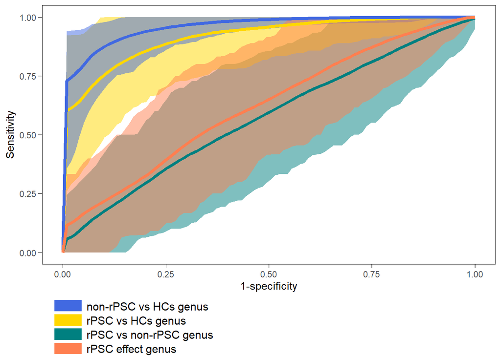

```r
roc_curve_all_custom(roc_cs[c(5:8)],Q="Q2",
                     model_name="enet_model")
```

**Supplementary models**

```r
# Build final dataframe
models_list[["enet_model"]] <- models_summ_df_ileum
final_df <- tibble(row_names = rownames(models_list[[1]]))

# Loop through models and extract required values
for (model_name in names(models_list)) {
  model_df <- models_list[[model_name]]

  # Combine AUC_optimism_corrected with its CI values
  final_df[[model_name]] <- paste0(
    round(model_df$auc_optimism_corrected, 3),
    " (", round(model_df$auc_optimism_corrected_CIL, 3), "; ",
    round(model_df$auc_optimism_corrected_CIU, 3), ")"
  )
}

knitr::kable(final_df, caption="All models")
```

All models

| row_names | knn_model | rf_model | gbm_model | enet_model_ra | knn_model_ra | rf_model_ra | gbm_model_ra | enet_model |
| --- | --- | --- | --- | --- | --- | --- | --- | --- |
| rPSC vs non-rPSC ASV terminal_ileum | 0.569 (0.377; 0.699) | 0.585 (0.498; 0.667) | 0.517 (0.402; 0.612) | 0.6 (0.5; 0.779) | 0.436 (0.344; 0.606) | 0.629 (0.544; 0.752) | 0.507 (0.406; 0.599) | 0.593 (0.477; 0.697) |
| rPSC vs healthy ASV terminal_ileum | 0.89 (0.82; 0.947) | 0.921 (0.794; 0.973) | 0.918 (0.854; 0.957) | 0.953 (0.888; 0.989) | 0.738 (0.585; 0.891) | 0.94 (0.868; 0.992) | 0.95 (0.915; 0.961) | 0.957 (0.896; 0.986) |
| non-rPSC vs healthy ASV terminal_ileum | 0.866 (0.76; 0.951) | 0.9 (0.799; 0.974) | 0.935 (0.868; 0.986) | 0.906 (0.829; 0.958) | 0.796 (0.732; 0.894) | 0.909 (0.861; 0.963) | 0.922 (0.862; 0.984) | 0.954 (0.89; 0.992) |
| rPSC effect ASV terminal_ileum | 0.637 (0.514; 0.758) | 0.551 (0.342; 0.686) | 0.609 (0.484; 0.671) | 0.569 (0.475; 0.665) | 0.601 (0.458; 0.708) | 0.635 (0.554; 0.712) | 0.639 (0.589; 0.71) | 0.655 (0.52; 0.767) |
| rPSC vs non-rPSC genus terminal_ileum | 0.518 (0.321; 0.685) | 0.577 (0.406; 0.745) | 0.551 (0.397; 0.71) | 0.59 (0.453; 0.747) | 0.525 (0.45; 0.625) | 0.634 (0.561; 0.742) | 0.449 (0.361; 0.541) | 0.574 (0.391; 0.732) |
| rPSC vs healthy genus terminal_ileum | 0.89 (0.752; 0.987) | 0.925 (0.821; 0.995) | 0.933 (0.841; 0.992) | 0.852 (0.665; 0.943) | 0.728 (0.564; 0.872) | 0.95 (0.872; 0.994) | 0.927 (0.861; 0.987) | 0.917 (0.805; 0.991) |
| non-rPSC vs healthy genus terminal_ileum | 0.911 (0.834; 0.968) | 0.917 (0.829; 0.985) | 0.941 (0.878; 0.99) | 0.909 (0.836; 0.96) | 0.827 (0.722; 0.889) | 0.93 (0.866; 0.984) | 0.952 (0.9; 0.995) | 0.961 (0.911; 0.992) |
| rPSC effect genus terminal_ileum | 0.548 (0.369; 0.725) | 0.578 (0.391; 0.747) | 0.567 (0.397; 0.724) | 0.536 (0.455; 0.682) | 0.546 (0.386; 0.653) | 0.616 (0.551; 0.711) | 0.615 (0.509; 0.777) | 0.623 (0.476; 0.786) |

**Supplementary ROC - genus**

```r
rocs_list <- supplements_models$roc_cs
rocs_list[["enet_model"]] <- roc_cs
plot_list <- list()

for (model_name in names(rocs_list)) {
  plot_list[[model_name]] <- roc_curve_all_custom(rocs_list[[model_name]][c(5:8)],
                       Q="Q2",
                       model_name=model_name)
}
```

```
## [1] "rPSC vs non-rPSC genus terminal_ileum"    "rPSC vs healthy genus terminal_ileum"
## [3] "non-rPSC vs healthy genus terminal_ileum" "rPSC effect genus terminal_ileum"
```

```
## [1] "rPSC vs non-rPSC genus terminal_ileum"    "rPSC vs healthy genus terminal_ileum"
## [3] "non-rPSC vs healthy genus terminal_ileum" "rPSC effect genus terminal_ileum"
```

```
## [1] "rPSC vs non-rPSC genus terminal_ileum"    "rPSC vs healthy genus terminal_ileum"
## [3] "non-rPSC vs healthy genus terminal_ileum" "rPSC effect genus terminal_ileum"
```

```
## [1] "rPSC vs non-rPSC genus terminal_ileum"    "rPSC vs healthy genus terminal_ileum"
## [3] "non-rPSC vs healthy genus terminal_ileum" "rPSC effect genus terminal_ileum"
```

```
## [1] "rPSC vs non-rPSC genus terminal_ileum"    "rPSC vs healthy genus terminal_ileum"
## [3] "non-rPSC vs healthy genus terminal_ileum" "rPSC effect genus terminal_ileum"
```

```
## [1] "rPSC vs non-rPSC genus terminal_ileum"    "rPSC vs healthy genus terminal_ileum"
## [3] "non-rPSC vs healthy genus terminal_ileum" "rPSC effect genus terminal_ileum"
```

```
## [1] "rPSC vs non-rPSC genus terminal_ileum"    "rPSC vs healthy genus terminal_ileum"
## [3] "non-rPSC vs healthy genus terminal_ileum" "rPSC effect genus terminal_ileum"
```

```
## [1] "rPSC vs non-rPSC genus terminal_ileum"    "rPSC vs healthy genus terminal_ileum"
## [3] "non-rPSC vs healthy genus terminal_ileum" "rPSC effect genus terminal_ileum"
```

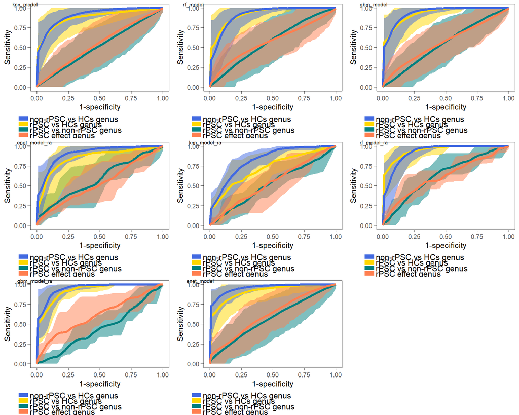

```r
p <- ggarrange(plotlist = plot_list,labels = names(rocs_list),font.label = list(face="plain",size=7))
p
```

# Data Analysis - Colon

```r
segment="colon"
```

## Filtering

Rules: - sequencing depth > 10000

- nearZeroVar() with default settings

**Rarefaction Curve**

```r
path="../intermediate_files/rarecurves"
seq_depth_threshold <- 10000
```

```r
ps <- construct_phyloseq(colon_asv_tab,colon_taxa_tab,colon_metadata)
rareres <- get_rarecurve(obj=ps, chunks=500)
save(rareres,file = file.path(path,"rarefaction_colon.Rdata"))
```

```r
load(file.path(path,"rarefaction_colon.Rdata"))
seq_depth_threshold <- 10000
prare <- ggrarecurve(obj=rareres,
                      factorNames="Country",
                      indexNames=c("Observe")) +
        theme_bw()+
        theme(axis.text=element_text(size=8),
              panel.grid=element_blank(),
              strip.background = element_rect(colour=NA,fill="grey"),
              strip.text.x = element_text(face="bold")) +
        geom_vline(xintercept = seq_depth_threshold,
                   linetype="dashed", color = "red") +
        xlim(0, 20000)
```

```
## The color has been set automatically, you can reset it manually by adding scale_color_manual(values=yourcolors)
```

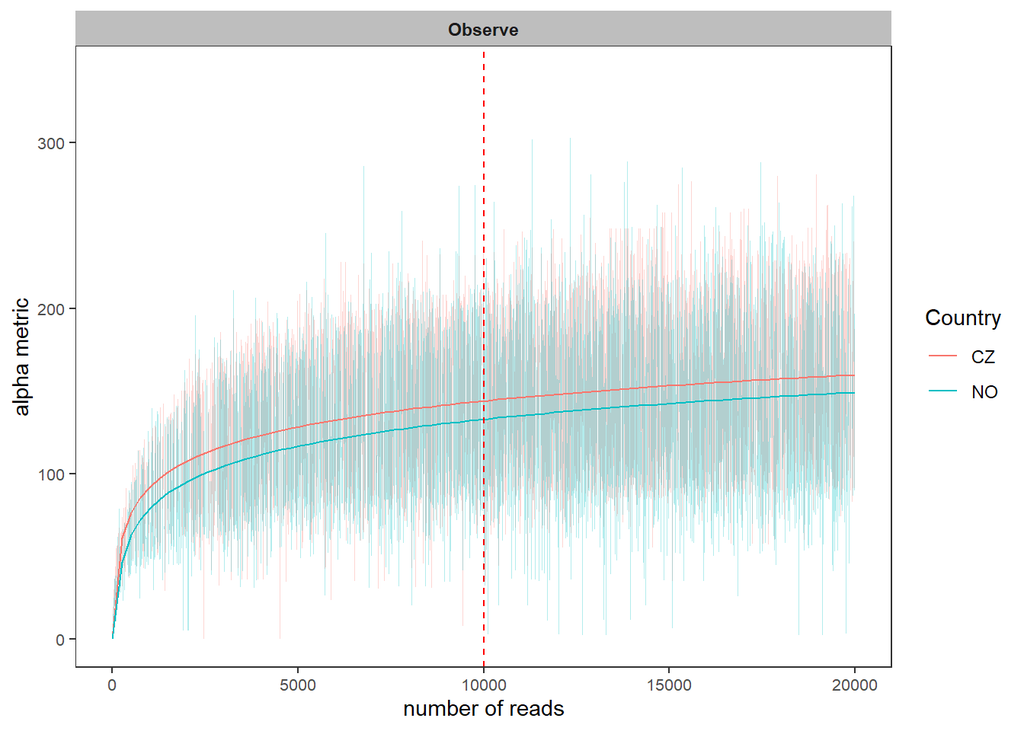

```r
prare
```

Library size

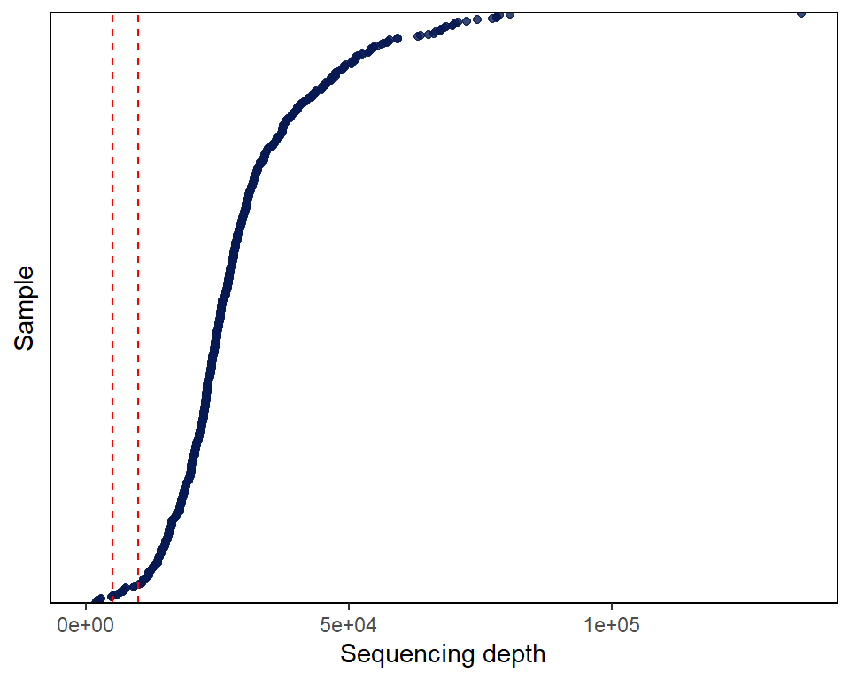

```r
read_counts(colon_asv_tab, line = c(5000,10000))
```

### Sequencing depth

```r
data_filt <- seq_depth_filtering(colon_asv_tab,
                                 colon_taxa_tab,
                                 colon_metadata,
                                 seq_depth_threshold = 10000)
```

```
## Removing 50 ASV(s)
```

```r
filt_colon_asv_tab <- data_filt[[1]]; alpha_colon_asv_tab <- filt_colon_asv_tab
filt_colon_taxa_tab <- data_filt[[2]]; alpha_colon_taxa_tab <- filt_colon_taxa_tab
filt_colon_metadata <- data_filt[[3]]; alpha_colon_metadata <- filt_colon_metadata

seq_step <- dim(filt_colon_asv_tab)[1]
```

Library size

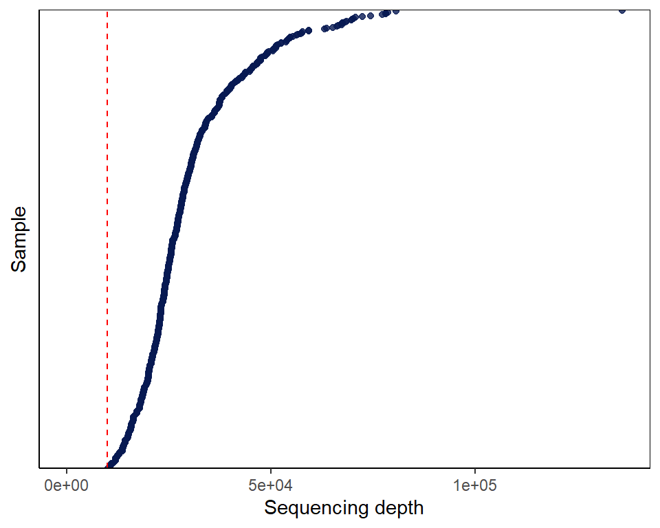

```r
read_counts(filt_colon_asv_tab,line = c(10000))
```

### NearZeroVar

```r
data_filt <- nearzerovar_filtering(filt_colon_asv_tab,
                                   filt_colon_taxa_tab,
                                   filt_colon_metadata)

filt_colon_asv_tab <- data_filt[[1]]
filt_colon_taxa_tab <- data_filt[[2]]
nearzero_step <- dim(filt_colon_asv_tab)[1]
```

Library size

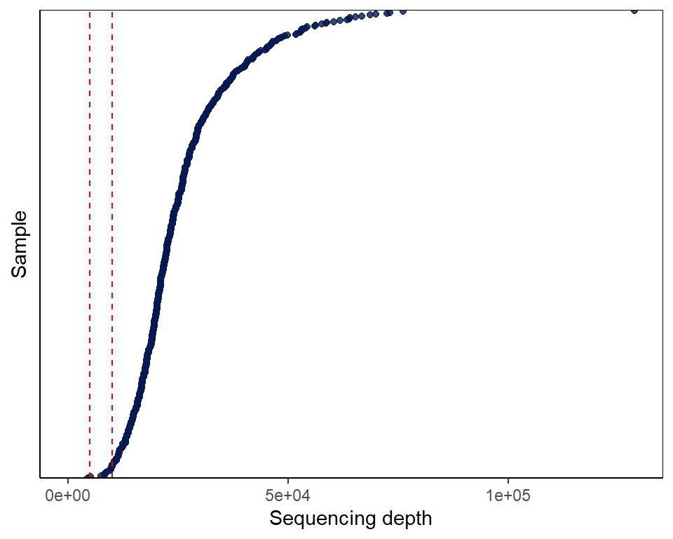

```r
read_counts(filt_colon_asv_tab,line = c(5000,10000))
```

Check zero depth

```r
data_filt <- check_zero_depth(filt_colon_asv_tab,
                              filt_colon_taxa_tab,
                              filt_colon_metadata)

filt_colon_asv_tab <- data_filt[[1]];
filt_colon_taxa_tab <- data_filt[[2]];
filt_colon_metadata <- data_filt[[3]];
```

Library size

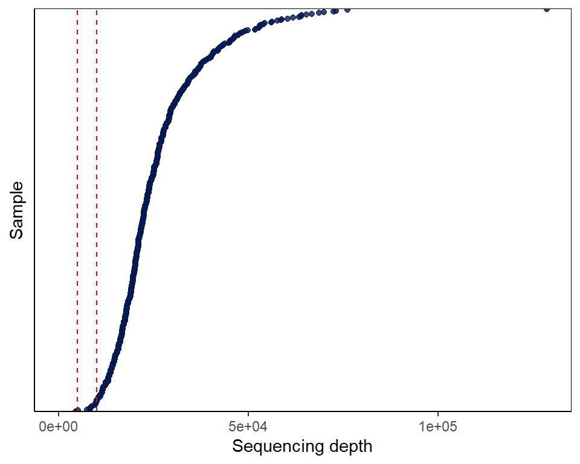

```r
read_counts(filt_colon_asv_tab,line = c(5000,10000))
```

### Final Counts

```r
final_counts_filtering(colon_asv_tab,
                       filt_colon_asv_tab,
                       filt_colon_metadata,
                       seq_step, 0, nearzero_step)
```

|  | V1 |
| --- | --- |
| Raw data: ASVs | 5840 |
| Raw data: Samples | 527 |
| Sequencing depth filt: ASVs | 5790 |
| Prevalence filt: ASVs | 0 |
| NearZeroVar filt: ASVs | 444 |
| Filt data: ASVs | 444 |
| Filt data: Samples | 511 |
| Filt data: Patients | 250 |
| Filt data: Patients.1 | 0 |
| Filtered samples | 16 |

[output cut: 7 more lines]

## Alpha diversity

```r
path = "../results/Q2/alpha_diversity"
```

**Calculation**

```r
# Construct MPSE object
alpha_colon_metadata$Sample <- alpha_colon_metadata$SampleID
colon_mpse <- as.MPSE(construct_phyloseq(alpha_colon_asv_tab,
                                         alpha_colon_taxa_tab,
                                         alpha_colon_metadata))

colon_mpse %<>% mp_rrarefy(raresize = 10000,seed = 123)

# Calculate alpha diversity - rarefied counts
colon_mpse %<>% mp_cal_alpha(.abundance=RareAbundance, force=TRUE)
```

```r
alpha_data <- data.frame(SampleID=colon_mpse$Sample.x,
                         Observe=colon_mpse$Observe,
                         Shannon=colon_mpse$Shannon,
                         Simpson=colon_mpse$Simpson,
                         Pielou=colon_mpse$Pielou,
                         Group=colon_mpse$Group,
                         Country=colon_mpse$Country,
                         Patient=colon_mpse$Patient)

write.csv(alpha_data,file.path(path,paste0("alpha_indices_",segment,".csv")),
          row.names = FALSE)
```

### Plots

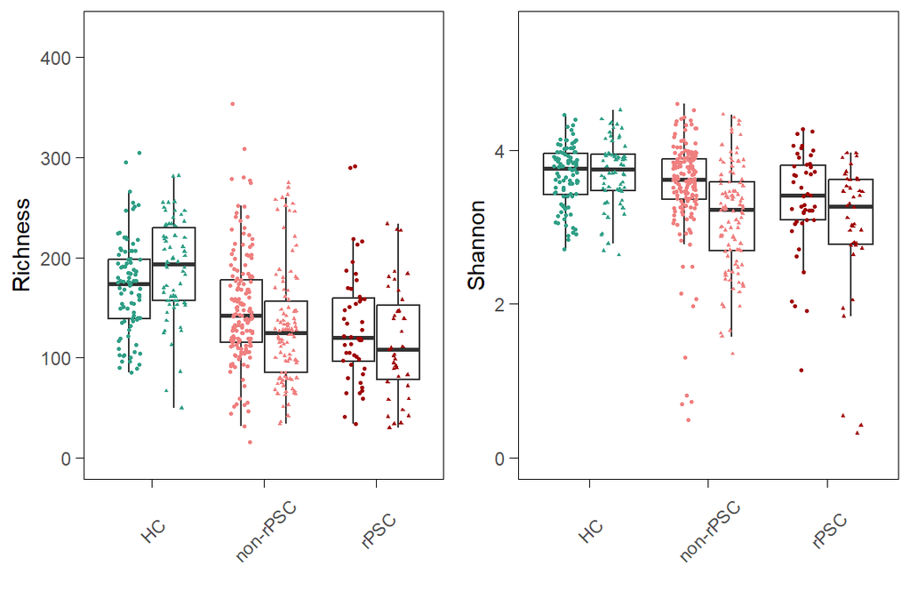

```r
p_boxplot_alpha <- alpha_diversity_countries(alpha_data)
# save the results
alpha_div_plots[[paste(segment,"Country")]] <- p_boxplot_alpha

# see the results
p_boxplot_alpha
```

### Linear Models

```r
path = "../results/Q2/alpha_diversity"
alpha_data <- read.csv(file.path(path,paste0("alpha_indices_",segment,".csv")))
```

**Richness**

```r
results_model <- pairwise.lmer(
  formula = "Observe ~ Group * Country + (1|Patient)",
  factors=alpha_data$Group,
  data=alpha_data)

# check interaction
if (!is.data.frame(results_model)){
  results_model_observe <- results_model[[1]]
  results_model_observe_detailed <- results_model[[2]]
} else {
  results_model_observe <- results_model
  results_model_observe_detailed <- NA
}

# save the results
pc_observed[[segment]] <- results_model_observe
```

```r
# see the results
knitr::kable(results_model_observe,digits = 3,
caption = "Raw results of linear model of richness estimation.")
```

Raw results of linear model of richness estimation.

|  | Estimate | Std..Error | df | t.value | Pr…t.. | p.adj | sig |
| --- | --- | --- | --- | --- | --- | --- | --- |
| non-rPSC vs GrouprPSC | -17.252 | 12.469 | 156.883 | -1.384 | 0.168 | 0.192 |  |
| non-rPSC vs rPSC - CZ vs NO | -17.941 | 10.644 | 153.303 | -1.686 | 0.094 | 0.192 |  |
| non-rPSC vs GrouprPSC:CountryNO | 3.483 | 21.371 | 152.108 | 0.163 | 0.871 | 0.871 |  |
| healthy vs GrouprPSC | -40.307 | 11.924 | 125.516 | -3.380 | 0.001 | 0.009 | ** |
| healthy vs rPSC - CZ vs NO | 14.783 | 10.544 | 126.613 | 1.402 | 0.163 | 0.192 |  |
| healthy vs GrouprPSC:CountryNO | -29.232 | 19.769 | 123.028 | -1.479 | 0.142 | 0.192 |  |
| healthy vs Groupnon-rPSC | -22.976 | 8.905 | 211.354 | -2.580 | 0.011 | 0.047 | * |
| healthy vs non-rPSC - CZ vs NO | 14.961 | 10.892 | 212.956 | 1.374 | 0.171 | 0.192 |  |
| healthy vs Groupnon-rPSC:CountryNO | -32.911 | 14.701 | 208.353 | -2.239 | 0.026 | 0.079 |  |

```r
knitr::kable(results_model_observe_detailed,digits = 3,
caption = "Raw results of independent country analysis")
```

Raw results of independent country analysis

|  | Estimate | Std. Error | df | t value | Pr(>\|t\|) | p.adjusted |
| --- | --- | --- | --- | --- | --- | --- |
| (Intercept) | 171.507 | 6.650 | 77.696 | 25.792 | 0.000 | NA |
| GrouprPSC | -40.316 | 11.792 | 76.971 | -3.419 | 0.001 | 0.002 |

|  | Estimate | Std. Error | df | t value | Pr(>\|t\|) | p.adjusted |
| --- | --- | --- | --- | --- | --- | --- |
| (Intercept) | 186.301 | 8.264 | 48.971 | 22.543 | 0 | NA |
| GrouprPSC | -69.557 | 16.036 | 46.963 | -4.338 | 0 | 0 |

|  | Estimate | Std. Error | df | t value | Pr(>\|t\|) | p.adjusted |
| --- | --- | --- | --- | --- | --- | --- |
| (Intercept) | 171.468 | 6.275 | 89.628 | 27.325 | 0.000 | NA |
| CountryNO | 14.904 | 9.836 | 89.468 | 1.515 | 0.133 | 0.178 |

|  | Estimate | Std. Error | df | t value | Pr(>\|t\|) | p.adjusted |
| --- | --- | --- | --- | --- | --- | --- |
| (Intercept) | 131.179 | 11.294 | 36.279 | 11.615 | 0.000 | NA |
| CountryNO | -14.435 | 19.236 | 35.739 | -0.750 | 0.458 | 0.458 |

|  | Estimate | Std. Error | df | t value | Pr(>\|t\|) | p.adjusted |
| --- | --- | --- | --- | --- | --- | --- |
| (Intercept) | 171.439 | 6.808 | 137.314 | 25.182 | 0.000 | NA |
| Groupnon-rPSC | -22.949 | 8.722 | 135.888 | -2.631 | 0.009 | 0.019 |

|  | Estimate | Std. Error | df | t value | Pr(>\|t\|) | p.adjusted |
| --- | --- | --- | --- | --- | --- | --- |
| (Intercept) | 186.365 | 8.682 | 75.472 | 21.467 | 0 | NA |
| Groupnon-rPSC | -55.850 | 12.120 | 73.619 | -4.608 | 0 | 0 |

|  | Estimate | Std. Error | df | t value | Pr(>\|t\|) | p.adjusted |
| --- | --- | --- | --- | --- | --- | --- |
| (Intercept) | 171.468 | 6.275 | 89.628 | 27.325 | 0.000 | NA |
| CountryNO | 14.904 | 9.836 | 89.468 | 1.515 | 0.133 | 0.133 |

|  | Estimate | Std. Error | df | t value | Pr(>\|t\|) | p.adjusted |
| --- | --- | --- | --- | --- | --- | --- |
| (Intercept) | 148.477 | 5.932 | 120.279 | 25.028 | 0.000 | NA |
| CountryNO | -17.950 | 10.519 | 117.183 | -1.706 | 0.091 | 0.121 |

**Shannon**

```r
results_model <- pairwise.lmer(
  formula = "Shannon ~ Group * Country + (1|Patient)",
  factors=alpha_data$Group,
  data=alpha_data)

# check interaction
if (!is.data.frame(results_model)){
  results_model_shannon <- results_model[[1]]
  results_model_shannon_detailed <- results_model[[2]]
} else {
  results_model_shannon <- results_model
  results_model_shannon_detailed <- NA
}

# save the results
pc_shannon[[segment]] <- as.data.frame(results_model_shannon)
```

```r
# see the results
knitr::kable(results_model_shannon,digits = 3,
caption = "Raw results of linear model of Shannon estimation.")
```

Raw results of linear model of Shannon estimation.

|  | Estimate | Std..Error | df | t.value | Pr…t.. | p.adj | sig |
| --- | --- | --- | --- | --- | --- | --- | --- |
| non-rPSC vs GrouprPSC | -0.146 | 0.161 | 154.485 | -0.907 | 0.366 | 0.549 |  |
| non-rPSC vs rPSC - CZ vs NO | -0.355 | 0.138 | 151.788 | -2.581 | 0.011 | 0.051 |  |
| non-rPSC vs GrouprPSC:CountryNO | 0.008 | 0.277 | 150.856 | 0.030 | 0.976 | 0.976 |  |
| healthy vs GrouprPSC | -0.330 | 0.128 | 126.201 | -2.572 | 0.011 | 0.051 |  |
| healthy vs rPSC - CZ vs NO | 0.017 | 0.113 | 127.217 | 0.146 | 0.884 | 0.976 |  |
| healthy vs GrouprPSC:CountryNO | -0.364 | 0.213 | 123.907 | -1.709 | 0.090 | 0.162 |  |
| healthy vs Groupnon-rPSC | -0.182 | 0.101 | 207.051 | -1.795 | 0.074 | 0.162 |  |
| healthy vs non-rPSC - CZ vs NO | 0.018 | 0.124 | 208.617 | 0.145 | 0.884 | 0.976 |  |
| healthy vs Groupnon-rPSC:CountryNO | -0.375 | 0.168 | 204.129 | -2.240 | 0.026 | 0.078 |  |

```r
knitr::kable(results_model_shannon_detailed,digits = 3,
caption = "Raw results of independent country analysis")
```

Raw results of independent country analysis

|  | Estimate | Std. Error | df | t value | Pr(>\|t\|) | p.adjusted |
| --- | --- | --- | --- | --- | --- | --- |
| (Intercept) | 3.683 | 0.065 | 77.802 | 56.300 | 0.000 | NA |
| GrouprPSC | -0.330 | 0.116 | 76.679 | -2.846 | 0.006 | 0.011 |

|  | Estimate | Std. Error | df | t value | Pr(>\|t\|) | p.adjusted |
| --- | --- | --- | --- | --- | --- | --- |
| (Intercept) | 3.700 | 0.099 | 48.693 | 37.40 | 0.000 | NA |
| GrouprPSC | -0.693 | 0.193 | 47.827 | -3.59 | 0.001 | 0.003 |

|  | Estimate | Std. Error | df | t value | Pr(>\|t\|) | p.adjusted |
| --- | --- | --- | --- | --- | --- | --- |
| (Intercept) | 3.683 | 0.054 | 89.061 | 68.505 | 0.000 | NA |
| CountryNO | 0.019 | 0.084 | 88.828 | 0.231 | 0.818 | 0.818 |

|  | Estimate | Std. Error | df | t value | Pr(>\|t\|) | p.adjusted |
| --- | --- | --- | --- | --- | --- | --- |
| (Intercept) | 3.354 | 0.153 | 36.206 | 21.939 | 0.000 | NA |
| CountryNO | -0.347 | 0.261 | 35.912 | -1.332 | 0.191 | 0.255 |

|  | Estimate | Std. Error | df | t value | Pr(>\|t\|) | p.adjusted |
| --- | --- | --- | --- | --- | --- | --- |
| (Intercept) | 3.684 | 0.081 | 133.503 | 45.582 | 0.000 | NA |
| Groupnon-rPSC | -0.184 | 0.104 | 132.547 | -1.772 | 0.079 | 0.105 |

|  | Estimate | Std. Error | df | t value | Pr(>\|t\|) | p.adjusted |
| --- | --- | --- | --- | --- | --- | --- |
| (Intercept) | 3.702 | 0.093 | 77.069 | 39.853 | 0 | NA |
| Groupnon-rPSC | -0.559 | 0.129 | 74.201 | -4.324 | 0 | 0 |

|  | Estimate | Std. Error | df | t value | Pr(>\|t\|) | p.adjusted |
| --- | --- | --- | --- | --- | --- | --- |
| (Intercept) | 3.683 | 0.054 | 89.061 | 68.505 | 0.000 | NA |
| CountryNO | 0.019 | 0.084 | 88.828 | 0.231 | 0.818 | 0.818 |

|  | Estimate | Std. Error | df | t value | Pr(>\|t\|) | p.adjusted |
| --- | --- | --- | --- | --- | --- | --- |
| (Intercept) | 3.501 | 0.075 | 117.089 | 46.588 | 0.000 | NA |
| CountryNO | -0.357 | 0.133 | 114.586 | -2.673 | 0.009 | 0.017 |

**Simpson**

```r
results_model <- pairwise.lmer(
  formula = "Simpson ~ Group * Country + (1|Patient)",
  factors=alpha_data$Group,
  data=alpha_data)

# check interaction
if (!is.data.frame(results_model)){
  results_model_simpson <- results_model[[1]]
  results_model_simpson_detailed <- results_model[[2]]
} else {
  results_model_simpson <- results_model
  results_model_simpson_detailed <- NA
}

# save the results
pc_simpson[[segment]] <- as.data.frame(results_model_simpson)
```

```r
# see the results
knitr::kable(results_model_simpson,digits = 3,
caption = "Raw results of linear model of Simpson estimation.")
```

Raw results of linear model of Simpson estimation.

|  | Estimate | Std..Error | df | t.value | Pr…t.. | p.adj | sig |
| --- | --- | --- | --- | --- | --- | --- | --- |
| non-rPSC vs GrouprPSC | -0.005 | 0.029 | 153.608 | -0.169 | 0.866 | 0.866 |  |
| non-rPSC vs rPSC - CZ vs NO | -0.032 | 0.024 | 151.251 | -1.296 | 0.197 | 0.443 |  |
| non-rPSC vs GrouprPSC:CountryNO | -0.027 | 0.049 | 150.427 | -0.554 | 0.581 | 0.806 |  |
| healthy vs GrouprPSC | -0.031 | 0.020 | 127.660 | -1.523 | 0.130 | 0.391 |  |
| healthy vs rPSC - CZ vs NO | -0.007 | 0.018 | 128.411 | -0.402 | 0.688 | 0.806 |  |
| healthy vs GrouprPSC:CountryNO | -0.052 | 0.034 | 125.982 | -1.540 | 0.126 | 0.391 |  |
| healthy vs Groupnon-rPSC | -0.026 | 0.016 | 201.924 | -1.600 | 0.111 | 0.391 |  |
| healthy vs non-rPSC - CZ vs NO | -0.007 | 0.020 | 203.469 | -0.363 | 0.717 | 0.806 |  |
| healthy vs Groupnon-rPSC:CountryNO | -0.025 | 0.026 | 199.046 | -0.952 | 0.342 | 0.616 |  |

```r
knitr::kable(results_model_simpson_detailed,digits = 3,
caption = "Raw results of independent country analysis")
```

Raw results of independent country analysis

|  | Estimate | Std. Error | df | t value | Pr(>\|t\|) | p.adjusted |
| --- | --- | --- | --- | --- | --- | --- |
| (Intercept) | 0.944 | 0.008 | 79.314 | 121.920 | 0.000 | NA |
| GrouprPSC | -0.031 | 0.014 | 77.978 | -2.245 | 0.028 | 0.057 |

|  | Estimate | Std. Error | df | t value | Pr(>\|t\|) | p.adjusted |
| --- | --- | --- | --- | --- | --- | --- |
| (Intercept) | 0.936 | 0.019 | 48.621 | 50.151 | 0.000 | NA |
| GrouprPSC | -0.082 | 0.037 | 48.125 | -2.258 | 0.029 | 0.057 |

|  | Estimate | Std. Error | df | t value | Pr(>\|t\|) | p.adjusted |
| --- | --- | --- | --- | --- | --- | --- |
| (Intercept) | 0.943 | 0.004 | 90.956 | 214.963 | 0.000 | NA |
| CountryNO | -0.007 | 0.007 | 90.564 | -0.990 | 0.325 | 0.325 |

|  | Estimate | Std. Error | df | t value | Pr(>\|t\|) | p.adjusted |
| --- | --- | --- | --- | --- | --- | --- |
| (Intercept) | 0.913 | 0.029 | 36.306 | 31.229 | 0.000 | NA |
| CountryNO | -0.059 | 0.050 | 36.048 | -1.181 | 0.245 | 0.325 |

**Pielou**

```r
results_model <- pairwise.lmer(
  formula = "Pielou ~ Group * Country + (1|Patient)",
  factors=alpha_data$Group,
  data=alpha_data)

# check interaction
if (!is.data.frame(results_model)){
  results_model_pielou <- results_model[[1]]
  results_model_pielou_detailed <- results_model[[2]]
} else {
  results_model_pielou <- results_model
  results_model_pielou_detailed <- NA
}

# save the results
pc_pielou[[segment]] <- as.data.frame(results_model_pielou)
```

```r
# see the results
knitr::kable(results_model_pielou,digits = 3,
caption = "Raw results of linear model of Pielou estimation.")
```

Raw results of linear model of Pielou estimation.

|  | Estimate | Std..Error | df | t.value | Pr…t.. | p.adj | sig |
| --- | --- | --- | --- | --- | --- | --- | --- |
| non-rPSC vs GrouprPSC | -0.007 | 0.026 | 153.863 | -0.292 | 0.771 | 0.843 |  |
| non-rPSC vs rPSC - CZ vs NO | -0.052 | 0.022 | 150.735 | -2.372 | 0.019 | 0.171 |  |
| non-rPSC vs GrouprPSC:CountryNO | -0.009 | 0.044 | 149.674 | -0.198 | 0.843 | 0.843 |  |
| healthy vs GrouprPSC | -0.023 | 0.020 | 127.665 | -1.183 | 0.239 | 0.538 |  |
| healthy vs rPSC - CZ vs NO | -0.008 | 0.017 | 129.013 | -0.457 | 0.648 | 0.843 |  |
| healthy vs GrouprPSC:CountryNO | -0.052 | 0.033 | 124.565 | -1.605 | 0.111 | 0.333 |  |
| healthy vs Groupnon-rPSC | -0.015 | 0.015 | 204.651 | -1.006 | 0.316 | 0.568 |  |
| healthy vs non-rPSC - CZ vs NO | -0.008 | 0.019 | 206.473 | -0.416 | 0.678 | 0.843 |  |
| healthy vs Groupnon-rPSC:CountryNO | -0.044 | 0.025 | 201.171 | -1.745 | 0.083 | 0.333 |  |

```r
knitr::kable(results_model_pielou_detailed,digits = 3,
caption = "Raw results of independent country analysis")
```

Raw results of independent country analysis

|  | Estimate | Std. Error | df | t value | Pr(>\|t\|) | p.adjusted |
| --- | --- | --- | --- | --- | --- | --- |
| (Intercept) | 0.720 | 0.009 | 78.395 | 76.134 | 0.000 | NA |
| GrouprPSC | -0.023 | 0.017 | 77.018 | -1.392 | 0.168 | 0.224 |

|  | Estimate | Std. Error | df | t value | Pr(>\|t\|) | p.adjusted |
| --- | --- | --- | --- | --- | --- | --- |
| (Intercept) | 0.712 | 0.016 | 49.474 | 44.366 | 0.000 | NA |
| GrouprPSC | -0.076 | 0.031 | 47.962 | -2.424 | 0.019 | 0.077 |

|  | Estimate | Std. Error | df | t value | Pr(>\|t\|) | p.adjusted |
| --- | --- | --- | --- | --- | --- | --- |
| (Intercept) | 0.720 | 0.007 | 89.185 | 99.650 | 0.000 | NA |
| CountryNO | -0.008 | 0.011 | 88.856 | -0.667 | 0.506 | 0.506 |

|  | Estimate | Std. Error | df | t value | Pr(>\|t\|) | p.adjusted |
| --- | --- | --- | --- | --- | --- | --- |
| (Intercept) | 0.697 | 0.025 | 36.449 | 27.771 | 0.000 | NA |
| CountryNO | -0.060 | 0.043 | 35.950 | -1.414 | 0.166 | 0.224 |

|  | Estimate | Std. Error | df | t value | Pr(>\|t\|) | p.adjusted |
| --- | --- | --- | --- | --- | --- | --- |
| (Intercept) | 0.720 | 0.013 | 132.894 | 56.00 | 0.000 | NA |
| Groupnon-rPSC | -0.016 | 0.016 | 132.038 | -0.97 | 0.334 | 0.445 |

|  | Estimate | Std. Error | df | t value | Pr(>\|t\|) | p.adjusted |
| --- | --- | --- | --- | --- | --- | --- |
| (Intercept) | 0.713 | 0.013 | 79.537 | 55.174 | 0.000 | NA |
| Groupnon-rPSC | -0.060 | 0.018 | 74.995 | -3.379 | 0.001 | 0.005 |

|  | Estimate | Std. Error | df | t value | Pr(>\|t\|) | p.adjusted |
| --- | --- | --- | --- | --- | --- | --- |
| (Intercept) | 0.720 | 0.007 | 89.185 | 99.650 | 0.000 | NA |
| CountryNO | -0.008 | 0.011 | 88.856 | -0.667 | 0.506 | 0.506 |

|  | Estimate | Std. Error | df | t value | Pr(>\|t\|) | p.adjusted |
| --- | --- | --- | --- | --- | --- | --- |
| (Intercept) | 0.705 | 0.012 | 115.555 | 60.129 | 0.000 | NA |
| CountryNO | -0.052 | 0.021 | 112.732 | -2.499 | 0.014 | 0.028 |

### Saving results

```r
alpha_list <- list(
  Richness=pc_observed[[segment]] %>% rownames_to_column("Comparison"),
  Shannon=pc_shannon[[segment]] %>% rownames_to_column("Comparison"),
  Simpson=pc_simpson[[segment]] %>% rownames_to_column("Comparison"),
  Pielou=pc_pielou[[segment]] %>% rownames_to_column("Comparison"))

write.xlsx(alpha_list,
           file = file.path(path,paste0("alpha_diversity_results_",segment,".xlsx")))
```